# CFA with R (`lavaan`)

Rafael Pentiado Poerschke

07 Julho, 2022

# 1 Let’s Start: On the Shop Floor

**Loading the packages**

```r
library(lavaan)
library(semPlot)
library(dplyr)
library(knitr)
library(kableExtra)
library(rstatix)
library(foreign)
library(psych)
library(tinytex)
library(EnvStats)
library(corrplot)
library(writexl)
```

**The `getwd()` returns an absolute filepath representing the current working directory of the R process;**

```r
getwd()
```

```
## [1] "/Users/rafaelpoerschke/GitHub/CFA_withR"
```

```r
#/Users/rafaelpoerschke/GitHub/CFA_withR
```

`setwd("dir")` **is used to set the working directory.**

```r
setwd("/Users/rafaelpoerschke/GitHub/CFA_withR")
```

## 1.1 Data Set

**Assumptions**: Check the multivariate normality; multicolinearity; sample size and Positive Definiteness of cov-var matrix.

Motivating example: Suppose you are a researcher studying the effects of student background on academic achievement. The dataset (worland5.csv) of 500 (*n=500*) students each with 9 observed variables.

**Observed Variables**:

Motivation, Harmony, Stability, Negative Parental Psychology, Socioeconomic Status (SES), Verbal IQ, Reading, Arithmetic and Spelling. The principal investigator hypothesizes three

**Latent Constructs**:

Adjustment, Risk, Achievement measured with its corresponding to the following codebook mapping:

### 1.1.1 Variables set 1

**1) Adjustment (Focus)**

- motiv: Motivation
- harm: Harmony
- stabI: Stability

**2) Risk**

- ppsych: (Negative) Parental Psychology
- ses: SES
- verbal: Verbal IQ

**3) Achievement**

- read: Reading
- arith: Arithmetic Skills
- spell: Spelling

### 1.1.2 Variables set 2

SPSS Anxiety Questionnaire (SAQ). The first eight items consist of the following (2,571 answers):

- q1: Statistics makes me cry
- q2: My friends will think I’m stupid for not being able to cope with SPSS
- q3: Standard deviations excite me
- q4: I dream that Pearson is attacking me with correlation coefficients
- q5: I don’t understand statistics
- q6: I have little experience with computers
- q7: All computers hate me
- q8: I have never been good at mathematics

You can load the file directly into R with the following command.

**Loading the data:**

```r
dat <- read.csv("/Users/rafaelpoerschke/GitHub/CFA_withR/worland5.csv")
#url <- "https://stats.idre.ucla.edu/wp-content/uploads/2021/02/worland5.csv"
#destfile <- "/Users/rafaelpoerschke/GitHub/CFA_withR/worland5.csv"
#download.file(url, destfile)
```

Importing a datafile from SPSS arquive (we will use it latter)

```r
dat1 <- read.spss("/Users/rafaelpoerschke/GitHub/CFA_withR/SAQ.sav", to.data.frame=TRUE, use.value.labels = FALSE)
#save(dat13, file = "dat1.RData")
#"https://stats.idre.ucla.edu/wp-content/uploads/2018/05/SAQ.sav"
```

How to Export a DataFrame to Excel File in R?

```r
#write_xlsx(dat1,"\database1.xlsx")
```

The most essential component of a structural equation model is covariance or the statistical relationship between items. The true population covariance, denoted $\mathbf{\Sigma}$, is called the variance-covariance matrix. Since we do not know $\mathbf{\Sigma}$ we can estimate it with our sample $\mathbf{\Sigma}(\theta)$, and call it $\mathbf{S}$, or the sample variance-covariance matrix.

The function `cov` specifies that we want to obtain the covariance matrix from the data.

```
**Question:** In this example, how the data are standardized, so if we try to extract the var-cov matrix, what we will have?
```

### 1.1.3 Basics metrics

#### 1.1.3.1 Covariance-Variance Matrix

**Covariance-Variance Table set1**

```r
#cov(dat)
```

#### 1.1.3.2 Correlation Matrix

**Correlation Table set1**

```r
#round(cov(dat[,1:9]),2)
```

#### 1.1.3.3 Covariance-Variance Matrix set2

**Covariance-Variance Table set2**

```r
round(cov(dat1[,1:8]),2)
```

```
##       q01   q02   q03   q04   q05   q06   q07   q08
## q01  0.69 -0.07 -0.30  0.34  0.32  0.20  0.28  0.24
## q02 -0.07  0.72  0.29 -0.09 -0.10 -0.07 -0.15 -0.04
## q03 -0.30  0.29  1.16 -0.39 -0.32 -0.27 -0.45 -0.24
## q04  0.34 -0.09 -0.39  0.90  0.37  0.30  0.43  0.29
## q05  0.32 -0.10 -0.32  0.37  0.93  0.28  0.36  0.23
## q06  0.20 -0.07 -0.27  0.30  0.28  1.26  0.64  0.22
## q07  0.28 -0.15 -0.45  0.43  0.36  0.64  1.22  0.29
## q08  0.24 -0.04 -0.24  0.29  0.23  0.22  0.29  0.76
```

#### 1.1.3.4 Correlation Matrix set2

**Correlation Table set2**

```r
round(cor(dat1[,1:8]),2)
```

```
##       q01   q02   q03   q04   q05   q06   q07   q08
## q01  1.00 -0.10 -0.34  0.44  0.40  0.22  0.31  0.33
## q02 -0.10  1.00  0.32 -0.11 -0.12 -0.07 -0.16 -0.05
## q03 -0.34  0.32  1.00 -0.38 -0.31 -0.23 -0.38 -0.26
## q04  0.44 -0.11 -0.38  1.00  0.40  0.28  0.41  0.35
## q05  0.40 -0.12 -0.31  0.40  1.00  0.26  0.34  0.27
## q06  0.22 -0.07 -0.23  0.28  0.26  1.00  0.51  0.22
## q07  0.31 -0.16 -0.38  0.41  0.34  0.51  1.00  0.30
## q08  0.33 -0.05 -0.26  0.35  0.27  0.22  0.30  1.00
```

The `kable` package allows fancier tables, what enable a clear visualization and navigation along it. Check it out!

**Correlation Table**

```r
kable(round(cor(dat[,1:8]),2)) %>%
  kable_styling(full_width = F, bootstrap_options = c("striped", "hover", "condensed", "responsive"))
```

|  | motiv | harm | stabi | ppsych | ses | verbal | read | arith |
| --- | --- | --- | --- | --- | --- | --- | --- | --- |
| motiv | 1.00 | 0.77 | 0.59 | -0.25 | 0.25 | 0.32 | 0.53 | 0.60 |
| harm | 0.77 | 1.00 | 0.58 | -0.25 | 0.26 | 0.25 | 0.42 | 0.44 |
| stabi | 0.59 | 0.58 | 1.00 | -0.16 | 0.18 | 0.27 | 0.36 | 0.38 |
| ppsych | -0.25 | -0.25 | -0.16 | 1.00 | -0.42 | -0.40 | -0.39 | -0.24 |
| ses | 0.25 | 0.26 | 0.18 | -0.42 | 1.00 | 0.40 | 0.43 | 0.37 |
| verbal | 0.32 | 0.25 | 0.27 | -0.40 | 0.40 | 1.00 | 0.56 | 0.49 |
| read | 0.53 | 0.42 | 0.36 | -0.39 | 0.43 | 0.56 | 1.00 | 0.73 |
| arith | 0.60 | 0.44 | 0.38 | -0.24 | 0.37 | 0.49 | 0.73 | 1.00 |

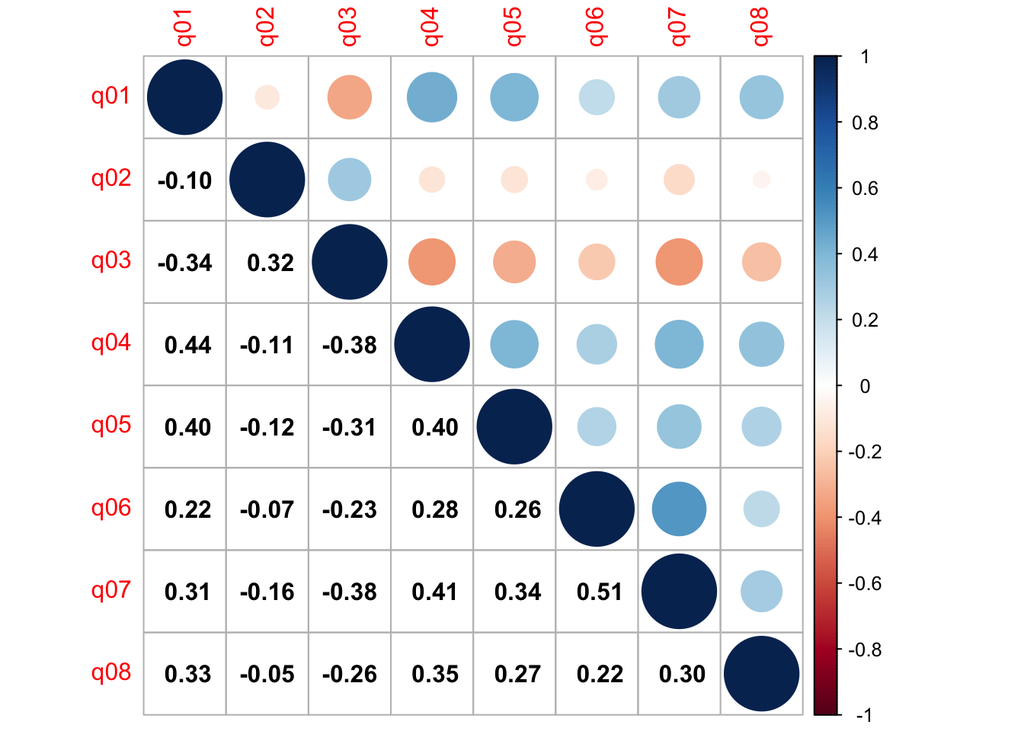

```r
mat1 <- cor(dat1[,1:8])
corrplot(mat1,type="upper",tl.pos="tp")
corrplot(mat1,add=T,type="lower", method="number",
col="black", diag=FALSE,tl.pos="n", cl.pos="n")
```

**Covariance-Variance Table**

```r
kable(round(cov(dat1[,3:5]),2)) %>%
  kable_styling(full_width = F, bootstrap_options = c("striped", "hover", "condensed", "responsive"))
```

|  | q03 | q04 | q05 |
| --- | --- | --- | --- |
| q03 | 1.16 | -0.39 | -0.32 |
| q04 | -0.39 | 0.90 | 0.37 |
| q05 | -0.32 | 0.37 | 0.93 |

## 1.2 Principal Components Analysis

In Principal Components Analysis - this and next subsection are based on Kent et al. (1979)[^1], and Johnson & Wichern (2014)[^2], we will find a **Y** matrix as a result of the transformation matrix **W**, what contais the eigenvectors in columns, over the variances-covariances matrix **X**.

$$\underbrace{\mathbf{Y}}_{(p \times p)} \: = \quad
\underbrace{\mathbf{W}^{T}}_{(p \times p)}
\underbrace{\mathbf{X}}_{(p \times p)}\:$$
The dataset (dat1) has 23 variables and 2571 observations, but we will focus just in the eight first questions. From it we can start to extract all necessary information. Let’s start checking the Principal Components, first lets compute the eigenvalues and the eigenvectors.

*Eigenvalues*

```r
R_set2 <- cor(dat1 [,1:8])
my.eigen = eigen(R_set2)
round(my.eigen$values, 3)
```

```
## [1] 3.057 1.067 0.958 0.736 0.622 0.571 0.543 0.446
```

*Eigenvectors*

```r
round(my.eigen$vectors,3)
```

```
##        [,1]   [,2]   [,3]   [,4]   [,5]   [,6]   [,7]   [,8]
## [1,]  0.377 -0.132  0.406  0.187 -0.081  0.752 -0.240  0.102
## [2,] -0.171 -0.839  0.026  0.108 -0.368 -0.224 -0.262 -0.002
## [3,] -0.374 -0.396 -0.083  0.075  0.520  0.336  0.513  0.212
## [4,]  0.412 -0.115  0.196  0.075 -0.366 -0.118  0.764 -0.205
## [5,]  0.372 -0.093  0.219  0.536  0.562 -0.431 -0.125 -0.015
## [6,]  0.327 -0.179 -0.690  0.036  0.135  0.233 -0.078 -0.553
## [7,]  0.411 -0.043 -0.463 -0.007 -0.115 -0.068  0.034  0.772
## [8,]  0.325 -0.258  0.226 -0.808  0.327 -0.111 -0.059 -0.018
```

How we can see, the first two are the ones that have values greater than the unit. Let’s check it out again:

```r
round(eigen(R_set2 [,1:8])$values, 3)
```

```
## [1] 3.057 1.067 0.958 0.736 0.622 0.571 0.543 0.446
```

Let’s do the same with the computed eigenvectors.

```r
round(eigen(R_set2 [,1:8])$vectors, 3)
```

```
##        [,1]   [,2]   [,3]   [,4]   [,5]   [,6]   [,7]   [,8]
## [1,]  0.377 -0.132  0.406  0.187 -0.081  0.752 -0.240  0.102
## [2,] -0.171 -0.839  0.026  0.108 -0.368 -0.224 -0.262 -0.002
## [3,] -0.374 -0.396 -0.083  0.075  0.520  0.336  0.513  0.212
## [4,]  0.412 -0.115  0.196  0.075 -0.366 -0.118  0.764 -0.205
## [5,]  0.372 -0.093  0.219  0.536  0.562 -0.431 -0.125 -0.015
## [6,]  0.327 -0.179 -0.690  0.036  0.135  0.233 -0.078 -0.553
## [7,]  0.411 -0.043 -0.463 -0.007 -0.115 -0.068  0.034  0.772
## [8,]  0.325 -0.258  0.226 -0.808  0.327 -0.111 -0.059 -0.018
```

Another way to extract the eigenvalues in R: The `prcomp( )` function produces an unrotated principal component analysis - it`s a native function. For now, we are not concerned if the PCs are or not rotated.

```r
pca_set2 <- prcomp(dat1 [,1:8],  scale = FALSE)  #ira normalizar os dados com o TRUE

round(pca_set2$rotation, 3) #componentes criados
```

```
##        PC1    PC2    PC3    PC4    PC5    PC6    PC7    PC8
## q01  0.276 -0.205  0.291 -0.019  0.118  0.027  0.155 -0.871
## q02 -0.137  0.266  0.542  0.290 -0.146  0.667 -0.259  0.024
## q03 -0.409  0.471  0.478 -0.186 -0.142 -0.521  0.225 -0.072
## q04  0.371 -0.190  0.308  0.150 -0.160  0.074  0.734  0.373
## q05  0.341 -0.188  0.387 -0.720 -0.017 -0.007 -0.356  0.231
## q06  0.419  0.701 -0.142 -0.137  0.502  0.145  0.141  0.021
## q07  0.492  0.306 -0.161  0.154 -0.720 -0.194 -0.214 -0.115
## q08  0.256 -0.094  0.321  0.545  0.385 -0.469 -0.357  0.173
```

## 1.3 Exploratory Factor Analysis

We can apply a complementary technique, i.e. Factor Analysis. Note that the **X** matrix is now on the left side, and **L** is the matrix of factor loadings.

$$\mathbf{X}_{p \times 1} \: = \:
\mu_{p \times 1} + \:
\mathbf {L}_{p \times m}\:\mathbf {F}_{m \times 1}\: + \:
\epsilon_{p \times 1}$$
The model above points that the observed variables variation depends on certain aleatory variable not direct observed, but we are able to estimate it as $F_{1},\: F_{2},\: \ldots, \:F_{q}$, and they are called . The model includes “$p$” sources of variations $\varepsilon_{1},\:\varepsilon_{2},\: \ldots, \:\varepsilon_{p}$, that are called .

We can write each variable with some association to the vector from $\;\mathbf{W}_{(p \times p)}$, but in EFA we are able to pic up “$\;m\;$” factors, with “$m \leq p$;” and from now on denoted $\mathbf{L}_{(p \times m)}$.
$$\hat{\mathbf{\Sigma}}\,=\, \underbrace{\hat{\mathbf{\Lambda}}_{x} \hat{\mathbf{\Lambda}}^{\prime}_{x}}_{\text{communality}} \; + \; \underbrace{\hat{\mathbf{\Psi}}_{\varepsilon}}_{\text{uniqueness}}$$

Where $\mathbf{\Lambda_{p \times k}}$ is the matrix **loadings**, and $\mathbf{\Psi}$ is a diagonal matrix of unique variances of observed variables.

The variability in our data, $\mathbf{X}$, is given by $\mathbf{\Sigma}$, and its estimate $\mathbf{\hat{\Sigma}}$ is composed of the variability explained by the factors explained be a linear combination of the factors (**communality**) and of the variability, which can not be explained by a linear combination of the factors (**uniqueness**).

Let’s check it out using `Psych` package. We have computed the eigenvalues, so we know the we need two of them (`dat1`), I mean, we need computed just the first two factors and apply an orthogonal rotation on it.

```r
fit <- fa(r = R_set2, nfactors = 2, fm = "ml", rotate = "Varimax")
loads <- fit$loadings[,1:2]
loads
```

```
##            ML1        ML2
## q01  0.2118908  0.6244710
## q02 -0.1421882 -0.1684692
## q03 -0.3280858 -0.4497037
## q04  0.3300947  0.5939122
## q05  0.2692136  0.5257771
## q06  0.5200163  0.1808952
## q07  0.9265564  0.1729263
## q08  0.2421117  0.4271415
```

The Factor number 1 is correlated with questions 06 and 07, so we can call it as the factor that measures the **Computer Knowledge**. On the other hand, Factor 2 are strongly associated ( $>$ 0.5) with q01, q04 and q05, and it measures the **statistics Knowledge**.

Remember tha the **loadings**, range from −1 to 1. This is the $\mathbf{\hat{\Lambda}}$in the equation above. The loadings are the contribution of each original variable to the factor. Variables with a high loading are well explained by the factor.

By squaring the loading we compute the fraction of the variable’s total variance explained by the factor. This proportion of the variability is denoted as **communality**. Another way to calculate the communality is to subtract the uniquenesses from 1.

*Communalities*

```r
commu_dat1 <- fit$communality[1:8]
commu_dat1
```

```
##        q01        q02        q03        q04        q05        q06        q07
## 0.43486175 0.04859935 0.30987365 0.46169422 0.34891751 0.30314006 0.88841020
##        q08
## 0.24106799
```

We can sum it, but why? It gives you the total (common) variance explained.

```r
soma_dat1 <- sum(commu_dat1)
soma_dat1
```

```
## [1] 3.036565
```

Than computing the uniquenesses

*Uniquenesses*

```r
uniq_dat1 <- fit$uniquenesses[1:8]
uniq_dat1
```

```
##       q01       q02       q03       q04       q05       q06       q07       q08
## 0.5651382 0.9514006 0.6901263 0.5383058 0.6510825 0.6968599 0.1115898 0.7589320
```

The first chunk provides the **uniquenesses**, which range from 0 to 1. The uniqueness, sometimes referred to as *noise*, corresponds to the proportion of variability, which by a linear combination of the factors. This is the $\hat{\Psi}$ in the equation above.

So we can sum it

```r
soma_unique_dat1 <- sum(uniq_dat1)
soma_unique_dat1
```

```
## [1] 4.963435
```

**NOTE**:

How many tests are we able to operate in EFA? May just check if the chosen number of factors are enough to explain the original variance. May we are able to choose a rotate method or estimators.

Joreskog (1969)[^3] proposed that a factor hypothesis could be tested by imposing restrictions on the EFA model — fixed elements in $\mathbf{\Lambda}$, $\mathbf{\Psi}$, usually 0. Needs more than $k^2$ restrictions. The ML solution is then found for the remaining free parameters.

The $\chi^2$ for the restricted solution gives a test for how well the hypothesized factor structure fits.

# 2 CONFIRMATORY FACTOR ANALYSIS (CFA)

All this section is based on Bollen (1989)[^4], Beaujeab (2014)[^5], Brown(2015)[^6], and Finch & French (2015)[^7].

Most social scientific concepts are not directly observable, e.g. intelligence, social capital, modernization. It makes them **hypothetical** or **latent** constructs. We can measure latent variables using **observable indicators**.

**The main objective** here is build a measurement model (data) that has behind it a Structural Model (theory) and check if they match.

## 2.1 Definitions

Variables Relationships in a Path Model

- **Observed variable**: a variable that exists in the data, a.k.a item or manifest variable.
- **Latent variable**: a variable that is constructed and does not exist in the data.
- **Exogenous variable**: an independent variable either observed (x) or latent ($\xi$) that explains an endogenous variable. With no direct cause (independent variables).
- **Endogenous variable**: a dependent variable, either observed (y) or latent ($\eta$) that has a causal path leading to it.
- **Measurement model**: a model that links observed variables with latent variables.
- **Indicator**: an observed variable in a measurement model (can be *exogenous* or *endogenous*).
- **Factor**: a latent variable defined by its indicators (can be *exogenous* or *endogenous*).
- **Loading**: a path between an indicator and a factor.
- **Structural model**: a model that specifies causal relationships among exogenous variables to endogenous variables (can be observed or latent)
- **Regression Path**: a path between exogenous and endogenous variables (can be observed or latent).

There is **subtlety** to the definition of an indicator. Although variables are typically seen as independent variables in a linear regression, the $x$ or $y$ label of an indicator in a measurement model depends on the factor it belongs to. An indicator is an $x$-side indicator if it depends on an *exogenous factor*(this is our case) and a $y$-side indicator if it depends on an *endogenous factor*.

## 2.2 The Lavaan Model Sintax

### 2.2.1 Regression Model

Regress onto: regression operator is (`~`), used for regression of observed outcome to observed predictors It has the following form:

#### 2.2.1.1 Model Description

```r
myModels <- list()
fits <- list()
myModels$Reg <- '
#Reg
motiv ~ ses+stabi+arith
'
```

#### 2.2.1.2 Diagram for a Regression Model

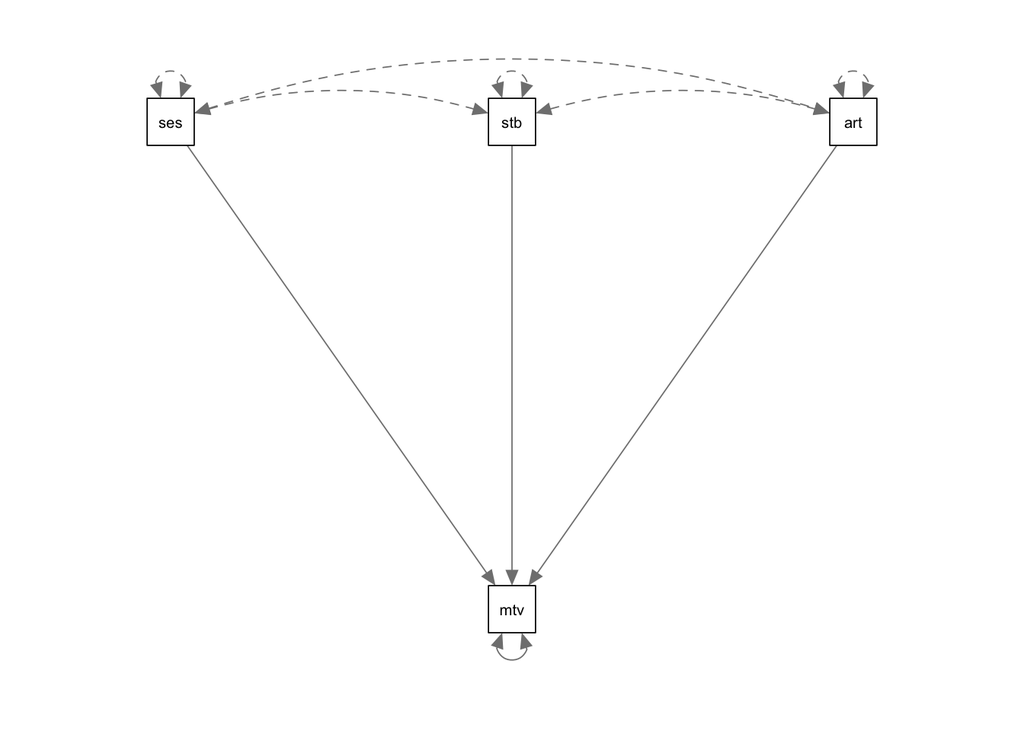

(`~1`) intercept or mean (e.g., `q01 ~ 1` estimates the mean of variable q01)

### 2.2.2 Latent variable definition

(`=~`) indicator, used for latent variable to observed indicator in factor analysis measurement models = (`f =~ y1+y2`) The factor causes the items.

We define them by listing their manifest variables

- **Reflective** latent variable (`=~`)
- - *Reflective*: All items measure the same construct. Direction of causality is from construct to measure (indicators), which means items are manifested by the construct. If interchangeable, and to a certain extent, it can even be removed. Measures expected to be correlated.
- - - **Diet**: (R1) I eat healthy food; (R2) I do not each much junk food; (R3) I have balanced Diet

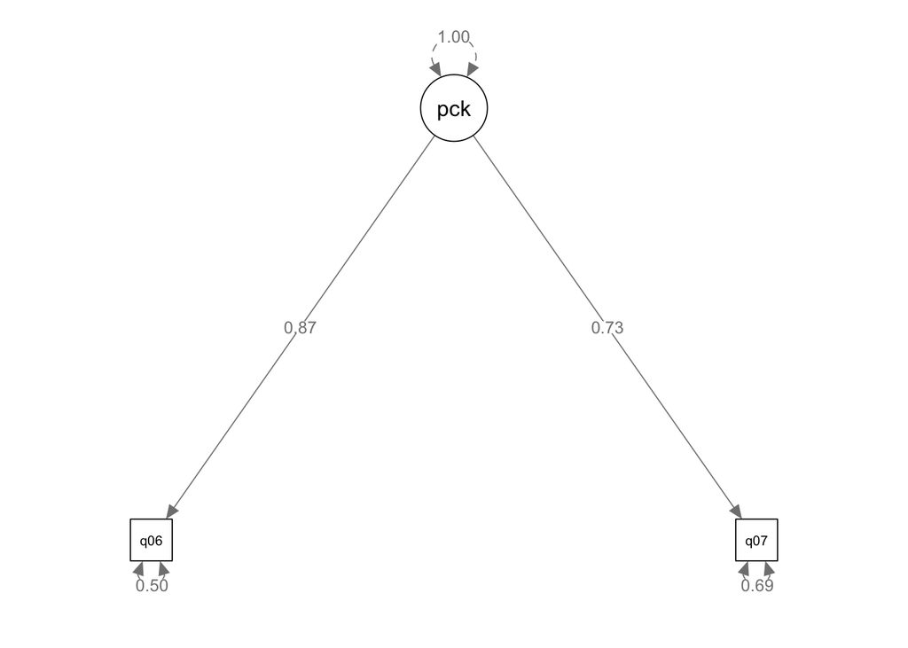

```r
myModels$Reflex <- '
#reflectiveconstruct
pcknow =~ q06 + q07
'

fits$Reflex <- lavaan::cfa(myModels$Reflex, data = dat1, std.lv=TRUE)
semPaths(fits$Reflex, whatLabels = "est", intercepts = FALSE, edge.label.cex = 0.9, edge.labels="both")
```

If q6 and q7 could covariate, we would have

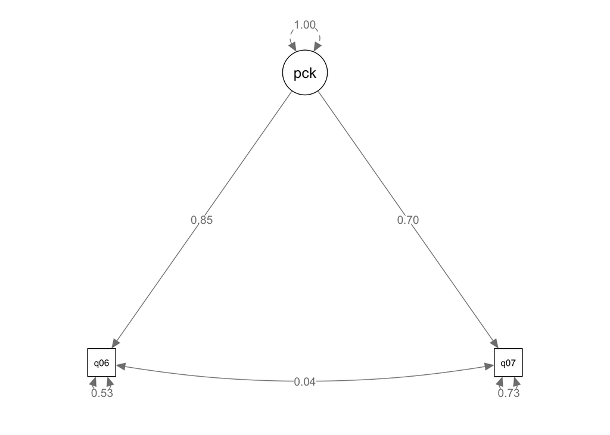

```r
myModels$Reflex <- '
#reflectiveconstruct
pcknow =~ q06 + q07

#covarianve
q06 ~~ q07
'
fits$Reflex <- lavaan::cfa(myModels$Reflex, data = dat1, std.lv=TRUE)
semPaths(fits$Reflex, whatLabels = "est", intercepts = FALSE, edge.label.cex = 0.9, edge.labels="both")
```

- **Formative** latent variable (`<~`)
- - *Formative*: Direction of causality is from **measure** to **construct**. The latent variable is considered a consequence of its respective indicators. Correlation not requires and indicators are not interchangeable, replacing a formative indicator will alter the meaning of the latent variable:
- - - **Health**: (F1) I have a balanced diet; (F2) I exercise regularly (F3); I get sufficient sleep each night.

### 2.2.3 Other usefull stuff

- (co)variance (`~~`): `x~~y`
- Intercept (`~1`): `x ~ 1` estimates the mean of $x$
- (`1*`) fixes parameter or loading to one: `f =~1*q`
- (`NA*`) frees parameter or loading (useful to override default marker method): `f =~NA*q`
- (`a*`) labels the parameter ‘a’, used for model constraints

## 2.3 Especification: A Complete Model Description

```
          > myModel <- `#regressions
          y1 ~ f1 + f2
          f1 ~ f2 + x3

          #latent variables definition
          f1 =~ x1 + x2 + x3
          f2 =~ x4 + x4

          #variances and covariances
          y1 ~~ y1
          y1 ~~ y2
          f1 ~~ f2

          #intercept
          y1 ~ 1`
```

We use Exploratory (EFA) when we have many variables and we have no idea how the items related with each other. In EFA each variable loads on all factors, and the number of latent variables are not determined before the analysis. The factors are assumed to be uncorrelated (Can use an oblique rotation to allow correlated factors).

**EFA has a limitation**, because the only true statistical tests in EFA are tests for the number of common factors (when estimated by ML). But CFA if you already have an hypothesis, the number of latent variables are set by the analyst and some effects of latent variables on observed variables are fixed to zero or some other constant.

In CFA you want to test your h0 so how well the sample can replicates covariance structure oh something knowing. Method for testing hypotheses about relationships among observed variables. Does this by imposing restrictions on an EFA model.

**Quest!**

- Question: Do the variables have a given factor structure?
- Question: How to compare competing models?

For EFA models, we start with the idea that each variable can be expressed as a regression on the common factors. For four variables, and one factor, $\xi$ (Csi), the model is

$$\begin{align}
X_{1}=\lambda_{1}\xi+\varepsilon_{1}\\
X_{2}=\lambda_{2}\xi+\varepsilon_{2}\\
X_{3}=\lambda_{3}\xi+\varepsilon_{3}\\
X_{4}=\lambda_{4}\xi+\varepsilon_{4}
\end{align}$$

and the **common factors** account for correlations among $x's$. The $\varepsilon_{i}$ are the errors terms, or **unique factors**.

For $m$ factors, the common model model is

$$\begin{align}
X_{1}=\lambda_{11}\xi_{1}+\lambda_{12}\xi_{2}+&\ldots+\lambda_{1m}\xi_{m}+\varepsilon_{1}\\
X_{2}=\lambda_{21}\xi_{1}+\lambda_{22}\xi_{2}+&\ldots+\lambda_{2m}\xi_{m}+\varepsilon_{2}\\
&\vdots\\
X_{p}=\lambda_{p1}\xi_{1}+\lambda_{p2}\xi_{2}+&\ldots+\lambda_{pm}\xi_{m}+\varepsilon_{p}
\end{align}$$

The $\lambda$’s are referred to as the **loadings**, because they indicate which variable “loads” on which factor. This is a EFA model with *m*-factors and *p*-observed variables.

Lets remember our model from `dat1` that one we found two factors in eight questions.

- The Factor number 1 ($\xi_{1}$) is correlated with question 06 and questions 07, so we called it of **Computer Knowledge** factor.
- On the other hand, Factor 2 ($\xi_{2}$), strongly correlated with question 01, 04 and 05, and it measures the **Statistics Knowledge**. Knowing *a priori* we may able to estimate the model as

$$\begin{align}
X_{6}=&\lambda_{61}\xi_{1}+\varepsilon_{6}\\
X_{7}=&\lambda_{71}\xi_{1}+\varepsilon_{7}\\
X_{1}=& &\lambda_{12}\xi_{2}+\varepsilon_{1}\\
X_{4}=& &\lambda_{42}\xi_{2}+\varepsilon_{4}\\
X_{5}=& &\lambda_{52}\xi_{2}+\varepsilon_{5}
\end{align}$$

The equation (1) represents this relation

$$\mathbf{X}\,=\,\mathbf{\Lambda}_{x}\mathbf{\Xi}\,+\,\varepsilon \tag{1}$$

$$\begin{bmatrix}
X_{6}\\
X_{7}\\
X_{1}\\
X_{4}\\
X_{5}
\end{bmatrix}
=
\begin{bmatrix}
\lambda_{61} & 0 \\
\lambda_{71} & 0 \\
0 & \lambda_{12} \\
0 & \lambda_{42} \\
0 & \lambda_{52} \\\\
\end{bmatrix}
.
\begin{bmatrix}
\xi_{1}\\
\xi_{2}\\
\end{bmatrix}
+
\begin{bmatrix}
\varepsilon_{6}\\
\varepsilon_{7}\\
\varepsilon_{1}\\
\varepsilon_{4}\\
\varepsilon_{5}
\end{bmatrix}$$
Each column of $\Lambda_{x}$ corresponds to one **latent variable**; the first column to $\xi_{1}$, and the second to $\xi_{2}$. The double subscript of $\lambda_{ij}$ indicates the row and column position in $\mathbf{\Lambda}_{x}$.

A zero in $\mathbf{\Lambda}_{x}$ indicates that the corresponding observed variable is not influenced by latent variable in that column. As EFA, $\lambda_{ij}$ describes the direct structural relation between a latent and observed variable - may be view as regression coefficients. Like in regression, the coefficient $\lambda_{ij}$ represents the number of units $x_{i}$ is expected to change for a one-unit change in $\xi_{j}$.

Before estimation, it is necessary to understand the relation of the covariance matrix of observed variables to the structural parameters of the model.

### 2.3.1 Diagram for a Reflective Model

When we applied the rotation in EFA, usually the option is for an orthogonal process. In that way we are looking for extract the maximum of the information inside the factors. This option could be applied in Lavaan:

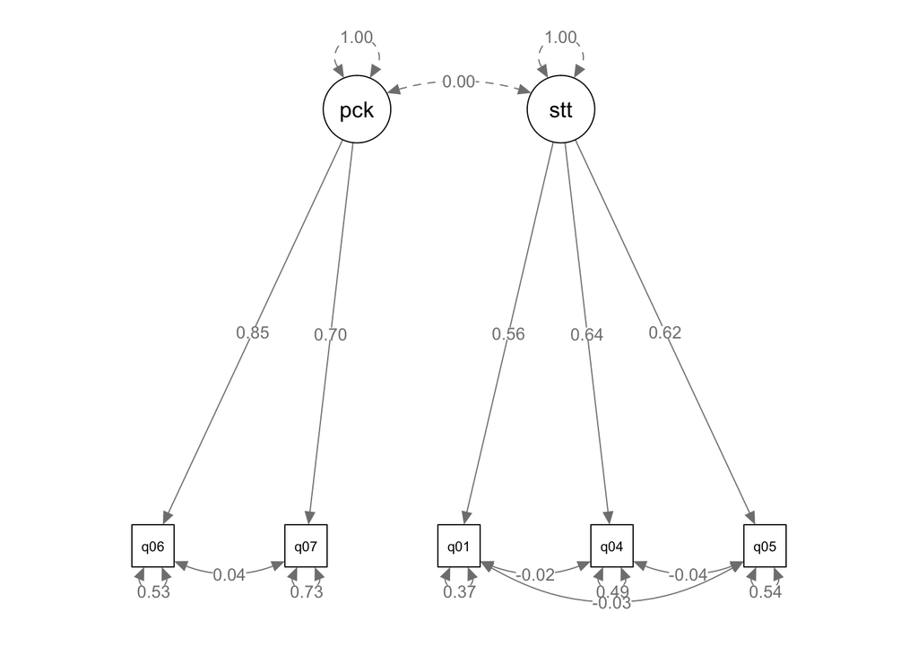

```r
myModels$Late <- '
#Reg
pcknow =~ q06 + q07
statknow =~ q01 + q04 + q05

#variances and covariances
              pcknow ~~ 0*statknow
              q06 ~~ q07
              q01 ~~ q04
              q01 ~~ q05
              q04 ~~ q05

'
```

But, think about these two latent variables, do they have any relation to each other? If you thought YES, we need to compute that information.

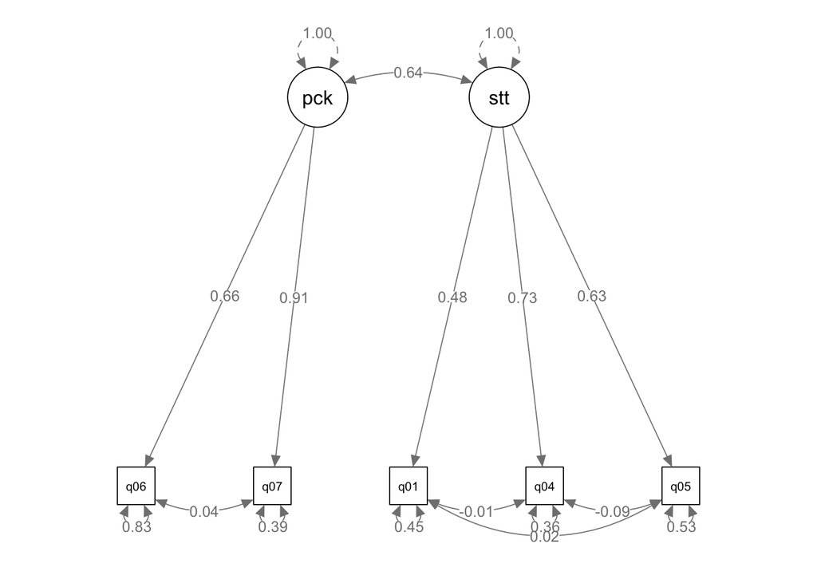

## 2.4 Model Implied Covariance

Historically, EFA is used to answer the question, how much common variance is shared among the items. This variance-covariance matrix can be described using the **model-implied covariance matrix** $\mathbf{\Sigma}(\Theta)$. Note that this is in contrast to the observed population covariance matrix $\mathbf{\Sigma}$ which comes only from the data. The formula for the model-implied covariance matrix is:

Model Implied Covariance (model) versus Covariance (data)

$$\underbrace{\mathbf{\Sigma}(\theta)=\mathbf{\Lambda}_{x} \mathbf{\Phi} \mathbf{\Lambda^{\prime}}_{x} \; + \; \mathbf{\Theta}_{\varepsilon}}_{\mathbf{Model}}
\; \; versus \; \; \underbrace{\mathbf{\Sigma}}_{\mathbf{Pop.}} \; \; versus \; \; \underbrace{\mathbf{S}=\hat{\mathbf{\Sigma}}}_{\mathbf{Sample \, Est.}}$$

- $\mathbf{\Lambda}_{x}$ **factor loading** matrix is $p \times q$ (consisting of the same $\lambda$’s from the measurement model);
- $\mathbf{\Phi}$ variance-convariance of the latent factors has $(q)(q+1)/2$ nonredudante parameters; and
- $\mathbf{\Theta}_{\varepsilon}$ variance-covariance of the residuals, has $(p)(p+1)/2$ unique parameters.

Remember equation (1), so we will have

$$\mathbf{\Lambda_{x}}
=
\begin{bmatrix}
\lambda_{61} & 0 \\
\lambda_{71} & 0 \\
0 & \lambda_{12} \\
0 & \lambda_{42} \\
0 & \lambda_{52} \\\\
\end{bmatrix}
; \quad
\mathbf{\Phi}
\begin{bmatrix}
\phi_{11} & \\
\phi_{21} & \phi_{22}\\
\end{bmatrix}
\\
\mathbf{\Theta}_{\varepsilon}=
\begin{bmatrix}
Var(\varepsilon_{6}) & & & &\\
0 & Var(\varepsilon_{7}) & \\
0 & 0 & Var(\varepsilon_{1})& \\
0 & 0 & 0 & Var(\varepsilon_{4})\\
0 & 0 & 0 & 0 & Var(\varepsilon_{5})
\end{bmatrix}
\\
\mathbf{\Sigma(\theta)}=
\begin{bmatrix}
\lambda^{2}_{61}\phi_{11}+Var(\varepsilon_{6}) & & & &\\
\lambda_{71}\lambda_{61}\phi_{11} & \lambda^{2}_{71}\phi_{11}+Var(\varepsilon_{7}) & \\
\lambda_{12}\lambda_{61}\phi_{12} & \lambda_{12}\lambda_{71}\phi_{12} & \lambda^{2}_{12}\phi_{22}+Var(\varepsilon_{1}) & \\
\lambda_{42}\lambda_{61}\phi_{12} & \lambda_{42}\lambda_{71}\phi_{12} & \lambda_{42}\lambda_{12}\phi_{22} & \lambda^{2}_{42}\phi_{22}+Var(\varepsilon_{4})\\
\lambda_{52}\lambda_{61}\phi_{12} & \lambda_{52}\lambda_{71}\phi_{12} & \lambda_{52}\lambda_{12}\phi_{22} & \lambda_{52}\lambda_{42}\phi_{22} & \lambda^{2}_{52}\phi_{22}+Var(\varepsilon_{5})
\end{bmatrix}$$
For instance, Var(q6) is $\lambda^{2}_{61}\phi_{11}+Var(\varepsilon_{6})$. So, the variance of question 6 indicator depends on $\lambda_{61}$, the coefficient linking it to **Computer Knowledge** ($\xi_{1}$), the variance ($\phi_{11}$) of this latent variable, and the measurement error variance ($Var(\varepsilon_{6})$) of the question 6.

**Quest!**

Do you think is feasible q6 and q7 covariate with each other?

$$\mathbf{\Theta}_{\varepsilon}=
\begin{bmatrix}
Var(\varepsilon_{6}) & & & &\\
Cov(\varepsilon_{6},\varepsilon_{7}) & Var(\varepsilon_{7}) & \\
0 & 0 & Var(\varepsilon_{1})& \\
0 & 0 & Cov(\varepsilon_{1},\varepsilon_{4}) & Var(\varepsilon_{4})\\
0 & 0 & Cov(\varepsilon_{1},\varepsilon_{5}) & Cov(\varepsilon_{4},\varepsilon_{5}) & Var(\varepsilon_{5})
\end{bmatrix}$$
So, the $Cov(q1,q5)$ is $\lambda_{12} \lambda_{52}\phi_{22}+Cov(\varepsilon_{1},\varepsilon_{5})$.

**Quest!**

Why $\mathbf{\Theta}_{\varepsilon}$ has $\frac{(p)(p+1)}{2}$ elements?

### 2.4.1 Mathematics appendix

Some assumptions of the factor analysis model

- mean of the intercepts is zero $E(\tau)=0$;
- mean of the factor is zero $E(\eta)=0$;
- mean of the residual is zero $E(\epsilon)=0$;
- covariance of the factor with the residual os zero $Cov(\eta,\epsilon)=0$.

**Expectation**

$$\begin{align}
\mu_{y} \, = \, E(\mathbf{y})\, & = \,E(\tau+\mathbf{\Lambda\eta}+\epsilon)\\
& =E(\tau)+E(\mathbf{\Lambda\eta})+E(\epsilon)\\
& =0+E(\mathbf{\Lambda\eta})+0\\
& =E(\mathbf{\Lambda\eta})\\
& =\mathbf{\Lambda}E(\eta)\\
& =\mathbf{\Lambda}\eta
\end{align}$$
**Covariance Structure**

$$\begin{align}
\mathbf{\Sigma}_{\theta} \, = \, Cov(\mathbf{y})\, & = \,E(\tau+\mathbf{\Lambda\eta}+\epsilon)\\
& =Var(\tau)+Var(\mathbf{\Lambda\eta})+Var(\epsilon)\\
& =0+Var(\mathbf{\Lambda\eta})+Var(\epsilon)\\
& =Var(\mathbf{\Lambda\eta})+Var(\epsilon)\\
& =\mathbf{\Lambda}Var(\eta)\mathbf{\Lambda}^{\prime}+Var(\epsilon)\\
& =\mathbf{\Lambda\Psi}\mathbf{\Lambda}^{\prime}+\mathbf{\Theta}_{\epsilon}
\end{align}$$

This is true due to the assumptions we made above and properties of covariance, such as the fact that the variance of a constant is zero and $Cov(\mathbf{AB})\mathbf{A}=\mathbf{A}Cov(\mathbf{B})\mathbf{A}^{\prime}$. We have defined new matrices where $Cov(\mathbf{\eta})=\mathbf{\Psi}$ is the variance-covariance matrix of the factors $\eta$ and $Var(\epsilon)=\mathbf{\Theta}_{\epsilon}$ is the variance of the residuals.

**Theorem**

Let $x \in \mathbb{R}^{p \times 1}$ be random (column) vector with covariance matrix $\mathbf{\Sigma} \in \mathbb{R}^{p \times p}$. Let $y = \mathbf{A}x$, where $\mathbf{A} \in \mathbb{R}^{n \times p}$ and $y \in \mathbb{R}^{n \times 1}$. Consider $\mathbf{\Sigma} \equiv Cov(\mathbf{X})=E[(x-E[x])(x-E[x])^{\prime}]$.

The theorem says that

$$Cov(\mathbf{A}x)=\mathbf{A}\Sigma\mathbf{A}^{\prime}.$$
Proof:

$$\begin{align}
Cov(y) \, = \, Cov(\mathbf{A}x)\, & = \,E[(\mathbf{A}x-E[\mathbf{A}x])(\mathbf{A}x-E[\mathbf{A}x])^{\prime}]\\
& =\,E[(\mathbf{A}x-\mathbf{A}E[x])(\mathbf{A}x-\mathbf{A}E[x])^{\prime}]\\
& =\,E[\mathbf{A}(x-E[x])(x-E[x])\mathbf{A}^{\prime}]\\
& =\,\mathbf{A}E[(x-E[x])(x-E[x])^{\prime}]\mathbf{A}^{\prime}\\
& =\,\mathbf{A}\mathbf{\Sigma}\mathbf{A}^{\prime}\\
& & \blacksquare
\end{align}$$

## 2.5 A Path Model: pictorial representation (diagram)

**Defined Model**

```r
#one factor three items, default marker method
myModels$m1a  <- ' f  =~ stabi + ppsych + ses'
```

Running model Raw data

```r
onefac3items_a <- lavaan::cfa(myModels$m1a, data=dat)
summary(onefac3items_a)
```

```
## lavaan 0.6-8 ended normally after 49 iterations
##
##   Estimator                                         ML
##   Optimization method                           NLMINB
##   Number of model parameters                         6
##
##   Number of observations                           500
##
## Model Test User Model:
##
##   Test statistic                                 0.000
##   Degrees of freedom                                 0
##
## Parameter Estimates:
##
##   Standard errors                             Standard
##   Information                                 Expected
##   Information saturated (h1) model          Structured
##
## Latent Variables:
##                    Estimate  Std.Err  z-value  P(>|z|)
##   f =~
##     stabi             1.000
##     ppsych           -2.333    0.593   -3.934    0.000
##     ses               2.625    0.737    3.564    0.000
##
## Variances:
##                    Estimate  Std.Err  z-value  P(>|z|)
##    .stabi            92.957    6.188   15.021    0.000
##    .ppsych           62.541   11.236    5.566    0.000
##    .ses              52.644   13.721    3.837    0.000
##     f                 6.843    3.001    2.280    0.023
```

or covs (input n)

```r
example.cov <- cov(dat1[,1:9])
fits$m4 <- lavaan::cfa(myModels$Latecov, sample.cov = example.cov, sample.nobs = 2571)
summary(fits$m4)
```

```
## lavaan 0.6-8 ended normally after 33 iterations
##
##   Estimator                                         ML
##   Optimization method                           NLMINB
##   Number of model parameters                        15
##
##   Number of observations                          2571
##
## Model Test User Model:
##
##   Test statistic                                 2.260
##   Degrees of freedom                                 0
##
## Parameter Estimates:
##
##   Standard errors                             Standard
##   Information                                 Expected
##   Information saturated (h1) model          Structured
##
## Latent Variables:
##                    Estimate  Std.Err  z-value  P(>|z|)
##   pcknow =~
##     q06               1.000
##     q07               1.387       NA
##   statknow =~
##     q01               1.000
##     q04               1.522       NA
##     q05               1.311       NA
##
## Covariances:
##                    Estimate  Std.Err  z-value  P(>|z|)
##   pcknow ~~
##     statknow          0.201       NA
##  .q06 ~~
##    .q07               0.191       NA
##  .q01 ~~
##    .q04               0.008       NA
##    .q05               0.033       NA
##  .q04 ~~
##    .q05              -0.072       NA
##
## Variances:
##                    Estimate  Std.Err  z-value  P(>|z|)
##    .q06               0.938       NA
##    .q07               0.599       NA
##    .q01               0.466       NA
##    .q04               0.391       NA
##    .q05               0.553       NA
##     pcknow            0.320       NA
##     statknow          0.220       NA
```

# 3 IDENTIFICATION

## 3.1 Degrees of Freedom

Then, $\mathbf{\Sigma}(\theta)$ is decomposed into:

- $\mathbf{\Lambda_{x}}$ matrix that has $pq$ elements;
- $\Phi$ has $(q)(q+1)/2$ nonredundant parameters, and
- $\mathbf{\Theta}_{\varepsilon}$ has $(p)(p+1)/2$ parameters.

Thus $\mathbf{\Sigma}(\theta)$ is decomposed into:

$$\boxed{pq\; +\; (q)(q+1)/2 \;+\;(p)(p+1)/2 \quad \quad \text{parameters.}}$$

With $p$ variables in $\mathbf{X}$, $\mathbf{\Sigma}$ has $(p)(p+1)/2$ **know-to-be-identified** elements.

So the number of **free parameters** in ($t$) must be less than or equal to the number of unique elements in the covariance matrix of $\mathbf{X}$.

$$\tag{2}
t \quad \leq \quad \frac{1}{2}(p)(p+1)$$

The *t-rule* present in (2) is a necessary but not sufficient condition for identification.

In regression models, identification is never an issue, just because they are always **just-identified** models. This mean that the number of parameters to estimate exactly equal the amount of non-redundant information in the data set.

**Known Values** or non-redundant variances/covariances in the data set matrix: total number of parameters.

The concept of a **fixed** or **free parameter** is essential in CFA. The total number of parameters in a CFA model is determined by the number of **known values** **($kv$)** in your population variance-covariance matrix $\Sigma$, given by the formula $(2)$ where $p$ is the number of items/manifest variables in your survey.

The **known values** serve as the primary restriction in terms of **how many total parameters we are able to estimate**. The known values serve as the upper limit of the number of parameters you can possibly estimate in our model. The parameters coming from the model are called model parameters and are calculates with (3).

$$\tag{3} \boxed{ \text{n. parameters}\;=\quad pq\; +\; \frac{(q)(q+1)}{2} \;+\;\frac{(p)(p+1)}{2} }$$
for $p$ variables and $q$ factors (latent).

Suppose the principal investigator thinks that the q1, q4 and q5 items of the SAQ are the observed indicators of Statknow. To obtain the sample covariance matrix $\mathbf{S}=\mathbf{\Sigma}$, which is an estimate of the population covariance matrix $\mathbf{\Sigma}$, use the command `select`, choose the interest columns, and the command `cov`. The function round with the option 2 specifies that we want to round the numbers to the second digit.

```r
latent <- select(dat1, q06, q07, q01, q04, q05)
round(cov(latent[,]),2)
```

```
##      q06  q07  q01  q04  q05
## q06 1.26 0.64 0.20 0.30 0.28
## q07 0.64 1.22 0.28 0.43 0.36
## q01 0.20 0.28 0.69 0.34 0.32
## q04 0.30 0.43 0.34 0.90 0.37
## q05 0.28 0.36 0.32 0.37 0.93
```

For the model of `statknow =~ q01 + q04 + q05` we have three items, so 3(3+1)/2 = 6 (since by symmetry, $\theta_{12}=\theta_{21},\, \theta_{13}=\theta_{31},\, \theta_{23}=\theta_{32}$) known values from the var-cov matrix.

Total parameters: one parameter from $y$ latent variable $\psi_{11}$ and 3 more parameters from $\lambda$’s. In total we have 10 **total parameters**, but we just have only 6 **known values**.

$$\boxed{ \text{n. parameters}\;=\quad 3 \times 1\; +\; \frac{(1)(1+1)}{2} \;+\;\frac{(3)(3+1)}{2} = \quad 10}$$
Let’s check the equation:
$$\begin{equation}
\tag{4}
\Sigma(\theta)=\underbrace{\begin{bmatrix}
\lambda_{1} \\
\lambda_{2} \\
\lambda_{3} \\
\end{bmatrix}
}_{\mathbf{loandings}} \underbrace{\begin{bmatrix}
(\psi_{11})
\end{bmatrix}
}_{\mathbf{variance \; of \; the \;factor}} \underbrace{\begin{bmatrix}
\lambda_{1} & \lambda_{2} & \lambda_{3} \\
\end{bmatrix}
}_{\mathbf{loadings}} + \underbrace{\begin{bmatrix}
\theta_{11} & - & - \\
\theta_{21} & \theta_{22} & - \\
\theta_{31} & \theta_{32} & \theta_{33} \\
\end{bmatrix}
}_{\mathbf{residual \; covariance}}
\end{equation}$$
The unique parameters in the model (4) are 10 (6 var-cov, 3 loadings e 1 factor var). Observe that we don`t have a fixed parameter (identification rules).

Not good, model is under identified (can find solution).

And changing for four items and one LV?
$$\begin{equation}
\tag{5}
\Sigma(\theta)=\underbrace{\begin{bmatrix}
\lambda_{1} \\
\lambda_{2} \\
\lambda_{3} \\
\lambda_{4} \\
\end{bmatrix}
}_{\mathbf{loandings}} \underbrace{\begin{bmatrix}
(\psi_{11})
\end{bmatrix}
}_{\mathbf{variance \; of \; the \;factor}} \underbrace{\begin{bmatrix}
\lambda_{1} & \lambda_{2} & \lambda_{3} & \lambda_{4} \\
\end{bmatrix}
}_{\mathbf{loadings}} + \underbrace{\begin{bmatrix}
\theta_{11} & - & - & - \\
0 & \theta_{22} & - & - \\
0 & 0 & \theta_{33} & \\
0 & 0 & 0 & \theta_{44} \\
\end{bmatrix}
}_{\mathbf{residual \; covariance}}
\end{equation}$$
For four items we will have **ten pieces** of non-redundant information: 4(4+1)/2 = 10. So, if the none of their error variances covary, we have 10 of unique parameters, and 9 number of free parameters (4 loadings, 4 variances and one variance of the factor ($\psi_{11}$). So we have a model overidentified.

**Free Parameters**

number of free parameters (**t**) = n of unique parameters - number of fixed parameters

So, the

**Degrees of Freedom**

degrees of freedom (**df**) = numb. of known values - number of free parameters

**Table!**

- **df negative**: known < fixed parameters (*under-identified* - cannot run )
- **df = 0**: **known** = fixed (*saturated or just-identified model* - no model fit statistics)
- **df positive**: **known** > fixed (*over-identified* - model fit stats can be assessed)

# 4 ESTIMATION

## 4.1 Defining the Metric of Latent Variable

How it is a latent variable, which is right metric for it?

**To standardize or not to standardize, that`s the question**

**a) standardized**: ($b^{*}$): better when comparing coefficients within the same model

**b) unstandardized** ($b$) (natural metric): comparing coefficients for the same variable relationships across samples or meaningful raw score units (dollar, height, age).

We have two ways to identify the model

### 4.1.1 Marked variable method

**Fixing the loads**: This method requires a single factor loading for each LV be constrained to an arbitrary value (usually the first one). Fixes the first loading (default in R) of the factors. We set the scale to that item to everything else.

**Usage:** You can use when you have the same scale items before…

$$\Sigma(\theta)=\underbrace{\begin{bmatrix}
1 \\
\lambda_{71} \\
1 \\
\lambda_{42} \\
\lambda_{52}
\end{bmatrix}
}_{\mathbf{loandings}} \underbrace{\begin{bmatrix}
\psi_{11} & \\
\psi_{12} & \psi_{22}
\end{bmatrix}
}_{\mathbf{variance \; of \; the \;factor}} \underbrace{\begin{bmatrix}
1 & \lambda_{71} & 1 & \lambda_{42} & \lambda_{52} \\
\end{bmatrix}
}_{\mathbf{loadings}} + \underbrace{\begin{bmatrix}
\theta_{66} & 0 & 0 & 0 & 0 \\
0 & \theta_{77} & 0 & 0 & 0 \\
0 & 0 & \theta_{11} & 0 & 0 \\
0 & 0 & 0 & \theta_{44} & 0 \\
0 & 0 & 0 & 0 & \theta_{55} \\
\end{bmatrix}
}_{\mathbf{residual \; covariance}}$$
So

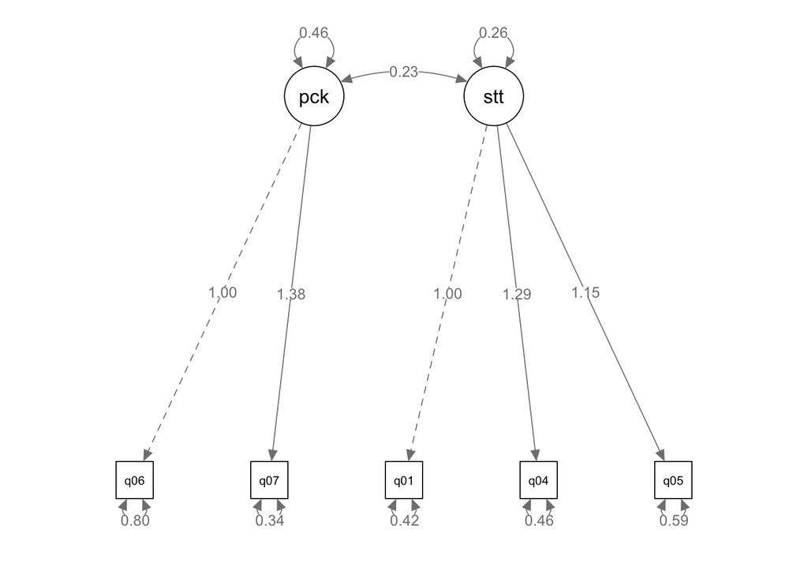

```r
summary(fits$Latecov)
```

```
## lavaan 0.6-8 ended normally after 29 iterations
##
##   Estimator                                         ML
##   Optimization method                           NLMINB
##   Number of model parameters                        11
##
##   Number of observations                          2571
##
## Model Test User Model:
##
##   Test statistic                                23.935
##   Degrees of freedom                                 4
##   P-value (Chi-square)                           0.000
##
## Parameter Estimates:
##
##   Standard errors                             Standard
##   Information                                 Expected
##   Information saturated (h1) model          Structured
##
## Latent Variables:
##                    Estimate  Std.Err  z-value  P(>|z|)
##   pcknow =~
##     q06               1.000
##     q07               1.384    0.074   18.640    0.000
##   statknow =~
##     q01               1.000
##     q04               1.289    0.058   22.336    0.000
##     q05               1.146    0.054   21.346    0.000
##
## Covariances:
##                    Estimate  Std.Err  z-value  P(>|z|)
##   pcknow ~~
##     statknow          0.225    0.016   14.269    0.000
##
## Variances:
##                    Estimate  Std.Err  z-value  P(>|z|)
##    .q06               0.800    0.031   25.496    0.000
##    .q07               0.336    0.043    7.760    0.000
##    .q01               0.423    0.016   26.869    0.000
##    .q04               0.463    0.021   22.247    0.000
##    .q05               0.585    0.021   27.350    0.000
##     pcknow            0.459    0.035   13.130    0.000
##     statknow          0.263    0.018   14.352    0.000
```

The interpretation is easy, first we have the loadings at the **Estimate** column (*q7*(1.384)) and `q6` as 1?

It means `lavaan` is fixing the first loading at 1 (marker method is the *default method*).

So it is a fixed parameter, there is no statistics for it, but the others are free estimates.

The number os free parameters are 13 minus 2 fixed parameters.

The *df* is 15 (unique parameters) - 11 = 4.

For one unit (in terms of item *q6*) increase in **Pcknow**, item **q7** goes up 1.384 points . In **Variances** we can see that variance of the factor, in scale of item `q6`, and the **dot** (.) means error.

### 4.1.2 Standardized Latent Variable

Fixing the variance of each factor to 1 but freely estimates of the all loadings. It makes a LV a standardized variable (Z-score - $z=(x-\mu_{x}) / \sigma_{x}$). If the indicator variables are also standardized, the loadings are interpreted as regression coefficients. Moreover, the covariance among the LV becomes a correlation.

Syntax no R

```r
#two factors, variance std
myModels$Latecov2 <- '
#Reg
pcknow =~ NA*q06 + q07
statknow =~ NA*q01 + q04 + q05

#variances and covariances
pcknow ~~ 1*pcknow
statknow ~~ 1*statknow
'

fits$Latecov2 <- lavaan::cfa(myModels$Latecov2, data = dat1, std.lv=FALSE)
```

Now what is it doing?

There is no blank row in estimated variables, and the $pcknow = statknow = 1$ in estimate variances. For one standard deviation increase in **Pcknow**, *q6* goes up 0.68 points.

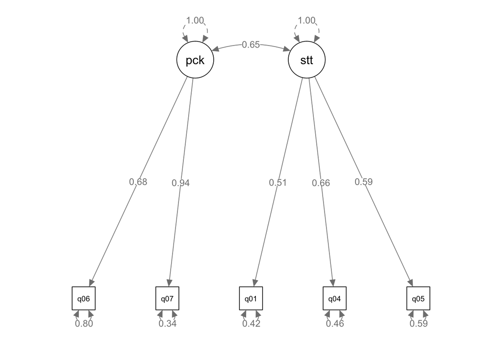

```r
lavaan::summary(fits$Latecov2, standardized=TRUE)
```

```
## lavaan 0.6-8 ended normally after 17 iterations
##
##   Estimator                                         ML
##   Optimization method                           NLMINB
##   Number of model parameters                        11
##
##   Number of observations                          2571
##
## Model Test User Model:
##
##   Test statistic                                23.935
##   Degrees of freedom                                 4
##   P-value (Chi-square)                           0.000
##
## Parameter Estimates:
##
##   Standard errors                             Standard
##   Information                                 Expected
##   Information saturated (h1) model          Structured
##
## Latent Variables:
##                    Estimate  Std.Err  z-value  P(>|z|)   Std.lv  Std.all
##   pcknow =~
##     q06               0.677    0.026   26.260    0.000    0.677    0.604
##     q07               0.938    0.028   32.956    0.000    0.938    0.851
##   statknow =~
##     q01               0.512    0.018   28.704    0.000    0.512    0.619
##     q04               0.661    0.020   32.333    0.000    0.661    0.697
##     q05               0.587    0.021   28.220    0.000    0.587    0.609
##
## Covariances:
##                    Estimate  Std.Err  z-value  P(>|z|)   Std.lv  Std.all
##   pcknow ~~
##     statknow          0.648    0.023   28.819    0.000    0.648    0.648
##
## Variances:
##                    Estimate  Std.Err  z-value  P(>|z|)   Std.lv  Std.all
##     pcknow            1.000                               1.000    1.000
##     statknow          1.000                               1.000    1.000
##    .q06               0.800    0.031   25.496    0.000    0.800    0.635
##    .q07               0.336    0.043    7.760    0.000    0.336    0.276
##    .q01               0.423    0.016   26.869    0.000    0.423    0.617
##    .q04               0.463    0.021   22.247    0.000    0.463    0.515
##    .q05               0.585    0.021   27.350    0.000    0.585    0.629
```

**Parameters**

```r
parameterEstimates(fits$Latecov2, standardized=TRUE)
```

```
##         lhs op      rhs   est    se      z pvalue ci.lower ci.upper std.lv
## 1    pcknow =~      q06 0.677 0.026 26.260      0    0.627    0.728  0.677
## 2    pcknow =~      q07 0.938 0.028 32.956      0    0.882    0.993  0.938
## 3  statknow =~      q01 0.512 0.018 28.704      0    0.477    0.547  0.512
## 4  statknow =~      q04 0.661 0.020 32.333      0    0.621    0.701  0.661
## 5  statknow =~      q05 0.587 0.021 28.220      0    0.547    0.628  0.587
## 6    pcknow ~~   pcknow 1.000 0.000     NA     NA    1.000    1.000  1.000
## 7  statknow ~~ statknow 1.000 0.000     NA     NA    1.000    1.000  1.000
## 8       q06 ~~      q06 0.800 0.031 25.496      0    0.738    0.861  0.800
## 9       q07 ~~      q07 0.336 0.043  7.760      0    0.251    0.421  0.336
## 10      q01 ~~      q01 0.423 0.016 26.869      0    0.392    0.454  0.423
## 11      q04 ~~      q04 0.463 0.021 22.247      0    0.422    0.504  0.463
## 12      q05 ~~      q05 0.585 0.021 27.350      0    0.543    0.627  0.585
## 13   pcknow ~~ statknow 0.648 0.023 28.819      0    0.604    0.693  0.648
##    std.all std.nox
## 1    0.604   0.604
## 2    0.851   0.851
## 3    0.619   0.619
## 4    0.697   0.697
## 5    0.609   0.609
## 6    1.000   1.000
## 7    1.000   1.000
## 8    0.635   0.635
## 9    0.276   0.276
## 10   0.617   0.617
## 11   0.515   0.515
## 12   0.629   0.629
## 13   0.648   0.648
```

**Nice Table with kableExtra**

```r
parameterEstimates(fits$Latecov2, standardized=TRUE) %>%
  filter(op == "=~") %>%
  select('Latent Fac'=lhs, Indicator=rhs, B=est, SE=se, Z=z, 'p-value'=pvalue, Beta=std.all) %>%
  kable(digits = 3, caption="Factor Loadings") %>%
  kable_styling(full_width = FALSE, bootstrap_options = c("striped", "hover", "responsive", "condensed"))
```

Factor Loadings

| Latent Fac | Indicator | B | SE | Z | p-value | Beta |
| --- | --- | --- | --- | --- | --- | --- |
| pcknow | q06 | 0.677 | 0.026 | 26.260 | 0 | 0.604 |
| pcknow | q07 | 0.938 | 0.028 | 32.956 | 0 | 0.851 |
| statknow | q01 | 0.512 | 0.018 | 28.704 | 0 | 0.619 |
| statknow | q04 | 0.661 | 0.020 | 32.333 | 0 | 0.697 |
| statknow | q05 | 0.587 | 0.021 | 28.220 | 0 | 0.609 |

Residuals

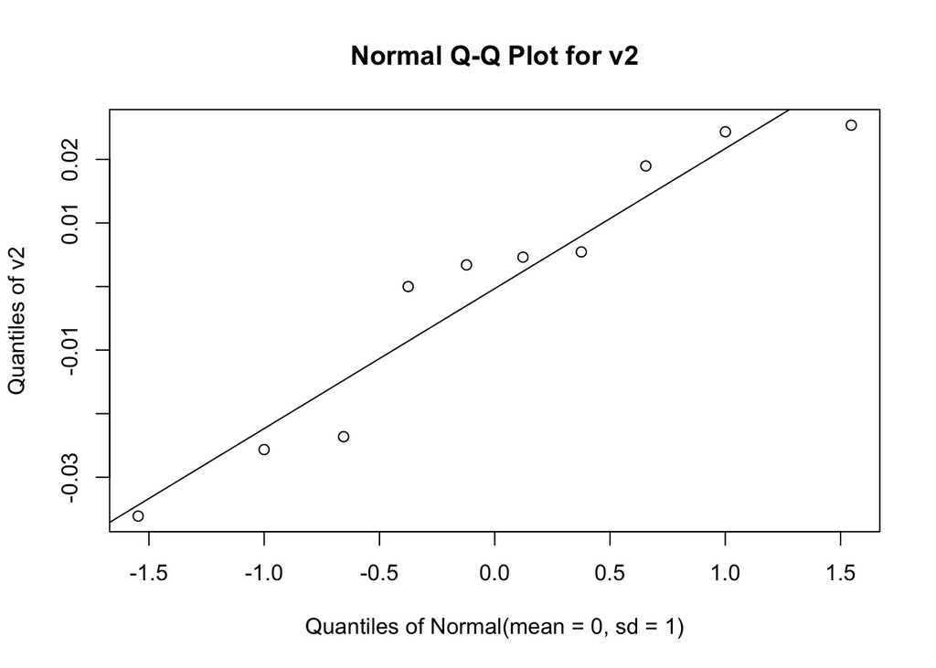

```r
# extract the residuals from the fit1 model
# get rid of the duplicates and diagonal values
# create a vector for a
#EnvStats pack
res1 <- residuals(fits$Latecov2, type = "cor")$cov
res1[upper.tri(res1,diag=T)] <- NA
v1 <- as.vector(res1)
v2 <- v1[!is.na(v1)]
qqPlot(v2,add.line = TRUE)
```

# 5 EVALUATION: Fit Statistics

Since we have an over-identified model, How well does this model fit?

## 5.1 A note on sample size: Does size matter?

Model chi-square is sensitive to large sample sizes, but does that mean we stick with small samples? The answer is no, larger samples are always preferred.

CFA and the general class of structural equation model are actually large sample techniques and much of the theory is based on the premise that your sample size is as large as possible. So how big of a sample do we need? Kline (2016)[^8] notes the *N:q* rule, which states that the sample size should be determined by the number of parameters in your model, and the recommended ratio is 20:1.

This means that if you have 10 parameters, you should have *n=200*. A sample size less than 100 is almost always untenable according to Kline (2016).

## 5.2 Exact Fit: Model chi-square

Is my model good enough to perfectly reproduce the population covariance matrix?

The model chi-square is proportional to the discrepancy of $\mathbf{\Sigma{(\hat{\theta}})}$ and $\mathbf{S}$, the higher the chi-square the more positive the value of $\mathbf{S} \, - \, \mathbf{\Sigma{(\hat{\theta}})}$, defined as residual covariance. It tests whether the covariance matrix derived from the model represents the population covariance.

$$\text{h}_{0}: \mathbf{\Sigma{(\theta})}=\mathbf{\Sigma}\\
\text{h}_{1}: \mathbf{\Sigma{(\theta})} \neq \mathbf{\Sigma}$$

Generally, chi-square is used as an **absolute fit index**, with a low chi-square value relative to the degrees of freedom (and higher p-value) indicating better model fit. Since the test is used to reject a null hypothesis representing perfect fit, chi-square is often referred to as a **‘badness of fit’** or **‘lack of fit index’**(ALAVI et al. )[^9].

The model chi-square is defined as $nF_{ml}$, and the $F_{ml}$ is the fit function from maximum likelihood

$$\boxed{F_{ml}\,=\,log|\mathbf{\hat{\Sigma}(\theta)}|+tr(\mathbf{S}\mathbf{\hat{\Sigma}^{-1}(\theta)})-log|\mathbf{S}|-(p+q)}$$
with $n$ as sample size, $p$ exogenous variables, and $q$ is the number of endogenous variables. So it`s $nF_{ml}\,\chi^{2}\, \sim \, (df_{\text{user}})$.

The Test Statistic is relatively large (23.935) and there is an additional row with P-value (Chi-square) indicating that we **reject the null hypothesis**.

```r
#Eight Item Two-Factor CFA and Latent Covs = 1 (Over-Identified)
summary(fits$Latecov2)
```

```
## lavaan 0.6-8 ended normally after 17 iterations
##
##   Estimator                                         ML
##   Optimization method                           NLMINB
##   Number of model parameters                        11
##
##   Number of observations                          2571
##
## Model Test User Model:
##
##   Test statistic                                23.935
##   Degrees of freedom                                 4
##   P-value (Chi-square)                           0.000
##
## Parameter Estimates:
##
##   Standard errors                             Standard
##   Information                                 Expected
##   Information saturated (h1) model          Structured
##
## Latent Variables:
##                    Estimate  Std.Err  z-value  P(>|z|)
##   pcknow =~
##     q06               0.677    0.026   26.260    0.000
##     q07               0.938    0.028   32.956    0.000
##   statknow =~
##     q01               0.512    0.018   28.704    0.000
##     q04               0.661    0.020   32.333    0.000
##     q05               0.587    0.021   28.220    0.000
##
## Covariances:
##                    Estimate  Std.Err  z-value  P(>|z|)
##   pcknow ~~
##     statknow          0.648    0.023   28.819    0.000
##
## Variances:
##                    Estimate  Std.Err  z-value  P(>|z|)
##     pcknow            1.000
##     statknow          1.000
##    .q06               0.800    0.031   25.496    0.000
##    .q07               0.336    0.043    7.760    0.000
##    .q01               0.423    0.016   26.869    0.000
##    .q04               0.463    0.021   22.247    0.000
##    .q05               0.585    0.021   27.350    0.000
```

The larger the chi-square value the larger the difference between the sample implied covariance matrix $\mathbf{\Sigma{(\hat{\theta}})}$ and the sample observed $\mathbf{S}$ covariance matrix, and the more likely you will reject your model.

**Prob do Chi-Square**

```r
#model chi-square
pchisq(q=23.935,df=4,lower.tail=FALSE)
```

```
## [1] 8.230705e-05
```

Since $p<0.05$, using the model chi-square criteria alone we reject the null hypothesis that the model fits the data.

It is well documented in CFA and SEM literature that the chi-square is often overly sensitive in model testing especially for large samples. For models with 75 to 200 cases chi-square is a reasonable measure of fit. Since the power of the model are positively correlated to the size of the sample (like in regression that we want to reject the null hypothesis), for 400 cases or more it is nearly almost always significant.

**Chi-squared** **Chisq**: The model Chi-squared assesses overall fit and the discrepancy

Between the sample and fitted covariance matrices. Its p-value should be >.05 (i.e., the hypothesis of a perfect fit cannot be rejected). However, it is quite sensitive to sample size.

## 5.3 Incremental versus absolute fit index

For over-identified models, there are many types of fit indexes available to the researcher. Historically, model chi-square was the only measure of fit but in practice the null hypothesis was often rejected due to the chi-square’s heightened sensitivity under large samples.

To resolve this problem, **approximate fit indexes** that were not based on accepting or rejecting the null hypothesis were developed. Approximate fit indexes can be further classified into

- 1. absolute and
- 2. incremental or relative fit indexes.

An incremental fit index (a.k.a. relative fit index) assesses the ratio of the deviation of the user model from the worst fitting model (a.k.a. the baseline model) against the deviation of the saturated model from the baseline model. Conceptually, if the deviation of the user model is the same as the deviation of the saturated model (a.k.a best fitting model), then the ratio should be 1. Alternatively, the more discrepant the two deviations, the closer the ratio is to 0 (see figure below).

Examples of **incremental** fit indexes are the *CFI* and *TLI*. An **absolute** fit index on the other hand, does not compare the user model against a baseline model, but instead compares it to the **observed data**. An example of an absolute fit index is the RMSEA.

## 5.4 Approximate Fit Index

### 5.4.1 (Optional) Model test of the baseline or null model

Before to check other statistics we need to check what a **baseline model** is.

The **model test baseline** is also known as the **null model**, where all covariances are set to zero and freely estimates variances. Rather than estimate the factor loadings, here we only estimate the observed means and variances (removing all the covariances). Recall that we have $p(p+1)/2$ covariances. Since we are only estimating the $p$ variances we have degrees of freedom, or in this particular model $p(p+1)/2-p$ degrees of freedom. You can verify in the output below that we indeed have 8 free parameters and 28 degrees of freedom.

```r
#Model Test User Model:
#Base Line model
myModels$base <- 'q01 ~~ q01
                  q02 ~~ q02
                  q03 ~~ q03
                  q04 ~~ q04
                  q05 ~~ q05
                  q06 ~~ q06
                  q07 ~~ q07
                  q08 ~~ q08'

#Running base model
onefac3items_base <- lavaan::cfa(myModels$base, data=dat1)
summary(onefac3items_base)
```

```
## lavaan 0.6-8 ended normally after 14 iterations
##
##   Estimator                                         ML
##   Optimization method                           NLMINB
##   Number of model parameters                         8
##
##   Number of observations                          2571
##
## Model Test User Model:
##
##   Test statistic                              4164.572
##   Degrees of freedom                                28
##   P-value (Chi-square)                           0.000
##
## Parameter Estimates:
##
##   Standard errors                             Standard
##   Information                                 Expected
##   Information saturated (h1) model          Structured
##
## Variances:
##                    Estimate  Std.Err  z-value  P(>|z|)
##     q01               0.685    0.019   35.854    0.000
##     q02               0.724    0.020   35.854    0.000
##     q03               1.155    0.032   35.854    0.000
##     q04               0.899    0.025   35.854    0.000
##     q05               0.930    0.026   35.854    0.000
##     q06               1.258    0.035   35.854    0.000
##     q07               1.215    0.034   35.854    0.000
##     q08               0.761    0.021   35.854    0.000
```

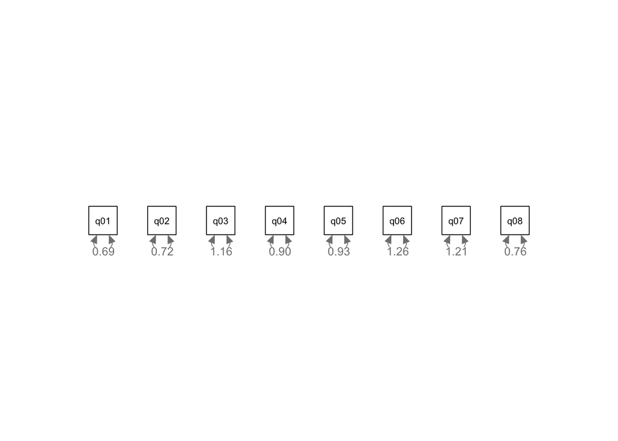

```r
semPaths(onefac3items_base, whatLabel = "est", edge.label.cex = 0.9, residuals = TRUE)
```

There is no factor predicting it, there is no residual, so the residual is the variance - with no covariances. This is the **baseline model**, the worst of them, because probably the variables are correlated with each other.

Think of the **null** or **baseline model** as the worst model you can come up with and the **saturated model** as the best model.

The **saturated model** or just identified, it is that with df=0.

So the **user model** will be the one is between the baseline and saturated model.

Theoretically, the baseline model is useful for understanding how other fit indices are calculated.

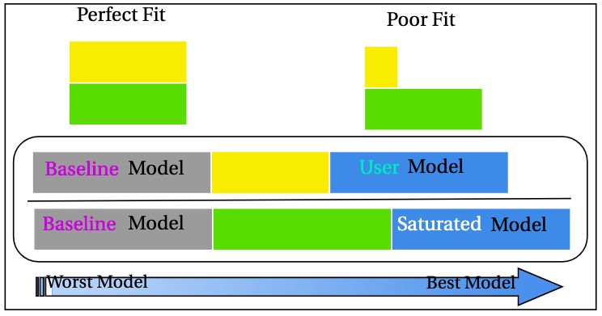

### 5.4.2 a) Incremental

#### 5.4.2.1 CFI

CFI is the Comparative Fit Index – values can range between 0 and 1 (values greater than 0.90, conservatively 0.95 indicate good fit). The CFI or comparative fit index is a popular fit index as a supplement to the model chi-square.

Let $\boxed{\delta=\chi^{2}-df}$ where $df$ is the degrees of freedom for that particular model.

The closer $\delta$ is to zero, the more the model fits the data.

The formula for the CFI is:
$$\boxed{CFI = \frac{\delta \text{(Baseline)}-\delta \text{(User)}}{\delta \text{(Baseline)}}}$$

Now, we will estimate our **model**:

```r
#one factor eight items, variance std
myModels$m3a <- 'f =~ q01 + q02 + q03 + q04 + q05 + q06 + q07 + q08'
onefac8items_a <- lavaan::cfa(myModels$m3a, data=dat1,std.lv=TRUE)
summary(onefac8items_a, fit.measures=TRUE, standardized=TRUE)
```

```
## lavaan 0.6-8 ended normally after 15 iterations
##
##   Estimator                                         ML
##   Optimization method                           NLMINB
##   Number of model parameters                        16
##
##   Number of observations                          2571
##
## Model Test User Model:
##
##   Test statistic                               554.191
##   Degrees of freedom                                20
##   P-value (Chi-square)                           0.000
##
## Model Test Baseline Model:
##
##   Test statistic                              4164.572
##   Degrees of freedom                                28
##   P-value                                        0.000
##
## User Model versus Baseline Model:
##
##   Comparative Fit Index (CFI)                    0.871
##   Tucker-Lewis Index (TLI)                       0.819
##
## Loglikelihood and Information Criteria:
##
##   Loglikelihood user model (H0)             -26629.559
##   Loglikelihood unrestricted model (H1)     -26352.464
##
##   Akaike (AIC)                               53291.118
##   Bayesian (BIC)                             53384.751
##   Sample-size adjusted Bayesian (BIC)        53333.914
##
## Root Mean Square Error of Approximation:
##
##   RMSEA                                          0.102
##   90 Percent confidence interval - lower         0.095
##   90 Percent confidence interval - upper         0.109
##   P-value RMSEA <= 0.05                          0.000
```

[output cut: 19 more lines]

```
##     q06               0.554    0.023   23.742    0.000    0.554    0.494
##     q07               0.716    0.022   32.761    0.000    0.716    0.650
##     q08               0.424    0.018   23.292    0.000    0.424    0.486
##
## Variances:
##                    Estimate  Std.Err  z-value  P(>|z|)   Std.lv  Std.all
##    .q01               0.450    0.015   30.734    0.000    0.450    0.656
##    .q02               0.685    0.019   35.300    0.000    0.685    0.946
##    .q03               0.780    0.025   31.157    0.000    0.780    0.675
##    .q04               0.499    0.018   27.989    0.000    0.499    0.555
##    .q05               0.623    0.020   31.040    0.000    0.623    0.670
##    .q06               0.951    0.029   32.711    0.000    0.951    0.756
##    .q07               0.702    0.024   28.678    0.000    0.702    0.578
##    .q08               0.581    0.018   32.849    0.000    0.581    0.764
##     f                 1.000                               1.000    1.000
```

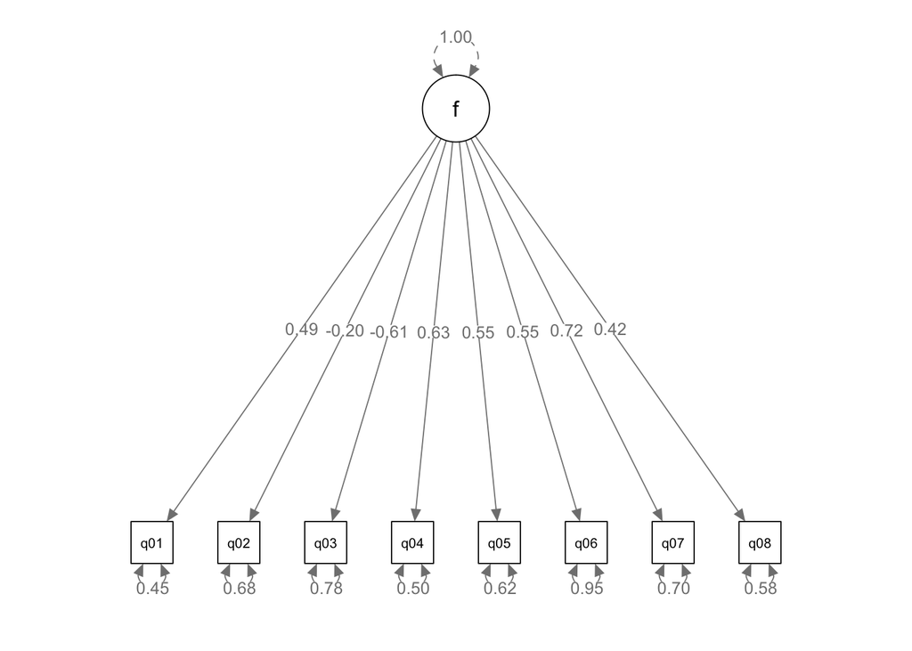

```r
semPaths(onefac8items_a, whatLabel = "est", edge.label.cex = 0.9, residuals = TRUE)
```

First calculate the number of total parameters, which are 8 loadings $\lambda_{1}, \ldots, \lambda_{8}$, 8 residual variances $\theta_{1},\ldots,\theta_{8}$, and 1 variance of the factor $\psi_{11}$. By the variance standardization method, we have fixed 1 parameter, namely. The number of free parameters is then:

$$\text{n. of free parameters}\,\,=\,\,17 \,\,\text{total parameters}\,\, - \,\, 1 \,\, \text{fixed parameters}\,\, = \quad 16.$$

Finally, there are $8(8+1)/2=36$ known values from the variance covariance matrix so the degrees of freedom is

$$df\,\,=\,\,36 \,\,\text{know values}\,\, - \,\, 16 \,\, \text{free parameters}\,\, = \quad 20.$$

$df\text{(Baseline)}=28$, and

$\chi^{2}\text{(User)}=554.191$ and

$\text{(User)}=20$.

So $\delta \text{(Baseline)}=4164.572-28=4136.572$ and $\delta \text{(User)}=554.191-20=534.191$. We can plug all of this into the following equation:

$$CFI \, = \, \frac{4136.572-534.191}{4136.572} \, = \, \frac{3602.381}{4136.572} \, = \, 0.871$$

If $\delta \text{(User)}=0$, then it means that the user model is not misspecified, so the numerator becomes $\text{(Baseline)}$ and the ratio becomes 1. The closer the CFI is to 1, the better the fit of the model; with the maximum being 1.

Some criteria claims 0.90 to 0.95 as a good cutoff for good fit.

**Comparative Fit Index** **CFI**:

The Comparative Fit Index is a revised form of NFI. Not very sensitive to sample size (Fan, Thompson, & Wang, 1999). Compares the fit of a target model to the fit of an independent, or null, model.

It should be >.90.

#### 5.4.2.2 Tucker-Lewis (TLI)

The term used in the Tucker Lewis Index TLI is the relative chi-square (a.k.a. normed chi-square) defined as $\frac{\chi^{2}}{df}$. Compared to the model chi-square, relative chi-square is less sensitive to sample size.

TLI which also ranges between 0 and 1 (if it’s greater than 1 it should be rounded to 1) with values greater than 0.90 indicating good fit. If the CFI and TLI are less than one, the CFI is always greater than the TLI.

The TLI formula is defined like:
$$TLI \, = \, \frac{min[\chi^2 \text{(Baseline)} / df \text{(Baseline)},1]-min[\chi^2 \text{(User)} / df \text{(User)},1]}{min[\chi^2 \text{(Baseline)} / df \text{(Baseline)},1]-1}$$
In the denominator we have a 1 since $\chi^2 \text{(Satureted)}=0$ and $df \text{(Satureted)}=0$ implies that $min(\chi^2 \text{(Satureted)}/df\text{(Satureted)},1)=1$. Also, the TLI can be greater than 1 but for practical purposes we round it to 1.

Given the eight-item one factor model:

$$TLI \, = \, \frac{4164.572/ 28-554.191 / 20}{4164.572 / 28-1} \, = \, \boxed{0.819}$$

**Tucker Lewis Index** **NNFI** (also called the **Tucker Lewis index**; TLI) is preferable for smaller samples. They should be > .90 (Byrne, 1994) or > .95 (Schumacker & Lomax,2004).

### 5.4.3 b) Absolute

#### 5.4.3.1 RMSEA

RMSEA is the root mean square error of approximation. The root mean square error of approximation is an absolute measure of fit because it does not compare the discrepancy of the user model relative to a baseline model like the CFI or TLI. Instead, RMSEA defines $\delta$ as the non-centrality parameter which measures the **degree of misspecification**. Recall from the CFI that $\delta=\chi^2-df$ where $df$ is the degrees of freedom for that particular model. The greater the $\delta$ the more misspefied the model.

$$\boxed{RMSE = \sqrt{\frac{\delta}{df(n-1)}}}$$
where $n$ is the total number of observations. The cutoff criteria as defined in Kline (2016, p.274-275)

**Table!**

- $\leq 0.05$ (**close-fit**)
- between $0.05$ and $0.08$ (reasonable approximate fit, fails close-fit but also fails poor-fit)
- $\geq 0.10$ (**poor-fit**)

In the case of our SAQ-8 factor analysis, $n=2,571$, $df(User)=20$ and $\delta (User)=534.191$ which we already known from calculating the CFI. Here $\delta$ is large relative to degrees of freedom.

$$RMSE = \sqrt{\frac{534.191}{20(2,571-1)}}=\sqrt{0.0104}=0.102$$
Our RMSEA = 0.10 indicating poor fit, as evidence by the large $\delta$ relative to the degrees of freedom.

**Root Mean Square Error Index** **RMSEA**: The Root Mean Square Error of Approximation is a parsimony-adjusted index. Values closer to 0 represent a good fit. It should be < .08 or < .05. The p-value printed with it tests the hypothesis that RMSEA is less than or equal to .05 (a cutoff sometimes used for good fit), and thus should be not significant.

### 5.4.4 SRMR

This is a badness of fit index, the bigger the value, the worse the fit. A SMSR lower or egual to 0.05 is a good fit and between 0.05 e 0.09 is considered an adequate fit (MacCallum et al. 1996)[^10]

**Root Mean Square Residual Index** **RMR/SRMR**: the (Standardized) Root Mean Square Residual represents the square-root of the difference between the residuals of the sample covariance matrix and the hypothesized model. As the RMR can be sometimes hard to interpret, better to use SRMR. Should be < .08.

# 6 INTERPRETATION

## 6.1 Standardized Solution in Lavaan

```r
# 2 factors 5 items, plain model
myModels$Latecov2_plain <- '
#Reg
pcknow =~ q06 + q07
statknow =~ q01 + q04 + q05

#variances and covariances

statknow ~~ pcknow

'
fits$Latecov2_plain <- lavaan::cfa(myModels$Latecov2_plain, data = dat1, meanstructure = FALSE)
summary(fits$Latecov2_plain, standardized=TRUE, fit.measures=TRUE)
```

```
## lavaan 0.6-8 ended normally after 29 iterations
##
##   Estimator                                         ML
##   Optimization method                           NLMINB
##   Number of model parameters                        11
##
##   Number of observations                          2571
##
## Model Test User Model:
##
##   Test statistic                                23.935
##   Degrees of freedom                                 4
##   P-value (Chi-square)                           0.000
##
## Model Test Baseline Model:
##
##   Test statistic                              2634.246
##   Degrees of freedom                                10
##   P-value                                        0.000
##
## User Model versus Baseline Model:
##
##   Comparative Fit Index (CFI)                    0.992
##   Tucker-Lewis Index (TLI)                       0.981
##
## Loglikelihood and Information Criteria:
##
##   Loglikelihood user model (H0)             -16765.895
##   Loglikelihood unrestricted model (H1)     -16753.928
##
##   Akaike (AIC)                               33553.790
##   Bayesian (BIC)                             33618.163
##   Sample-size adjusted Bayesian (BIC)        33583.212
##
## Root Mean Square Error of Approximation:
##
##   RMSEA                                          0.044
##   90 Percent confidence interval - lower         0.028
##   90 Percent confidence interval - upper         0.062
##   P-value RMSEA <= 0.05                          0.685
```

[output cut: 20 more lines]

```
##
## Covariances:
##                    Estimate  Std.Err  z-value  P(>|z|)   Std.lv  Std.all
##   pcknow ~~
##     statknow          0.225    0.016   14.269    0.000    0.648    0.648
##
## Variances:
##                    Estimate  Std.Err  z-value  P(>|z|)   Std.lv  Std.all
##    .q06               0.800    0.031   25.496    0.000    0.800    0.635
##    .q07               0.336    0.043    7.760    0.000    0.336    0.276
##    .q01               0.423    0.016   26.869    0.000    0.423    0.617
##    .q04               0.463    0.021   22.247    0.000    0.463    0.515
##    .q05               0.585    0.021   27.350    0.000    0.585    0.629
##     pcknow            0.459    0.035   13.130    0.000    1.000    1.000
##     statknow          0.263    0.018   14.352    0.000    1.000    1.000
```

```r
# standardized=TRUE will show us all methods (marker, variance and automatic standardized)
```

Notice that there are two additional columns, `Std.lv` (variance standardized) and `Std.all`.

Comparing the two solutions, the loadings and variance of the factors are different but the residual variances are the same.

**Interpretation** ~~~

I mean, for one standard deviation in **Pcknow**, **q6** goes up to 0.604 standard deviation units. ~~~

Since we have the correlation between factor and indicators, squaring a completely standardized factor loading provides the proportion of variance in the indicator that is explained by the latent factor. For example, **pcknow** accounts for 36,5% of the variance in the indicator **q6** ($0,604^{2}=0,3648$). So, 63% ($1-0,604^{2}=0.6352$) of the observed variance in **q6** is estimated to be unique or error variance.

## 6.2 Modification Index

The Modification Index reflects an approximation of how much the overall model $\chi^{2}$ would decrease in the fixed or constrained parameter was freely estimated.

Modification indices can be requested by adding the argument `modindices = TRUE` in the `summary()` call, or by calling the function `modindices()` directly. By default, modification indices are printed out for each nonfree (or fixed-to-zero) parameter.

The modification indices are supplemented by the **expected parameter change (EPC)** values (column epc). The last three columns contain the standardized EPC values (sepc.lv: only standardizing the latent variables; sepc.all: standardizing all variables; sepc.nox: standardizing all but exogenous observed variables).

Let`s run baseline model

```r
modindices(fits$Latecov2_plain, sort = TRUE)
```

```
##       lhs op rhs     mi    epc sepc.lv sepc.all sepc.nox
## 14 pcknow =~ q01 19.180 -0.204  -0.138   -0.167   -0.167
## 28    q04 ~~ q05 19.180 -0.094  -0.094   -0.180   -0.180
## 15 pcknow =~ q04 11.912  0.205   0.139    0.146    0.146
## 27    q01 ~~ q05 11.912  0.057   0.057    0.114    0.114
## 24    q07 ~~ q04 10.677  0.059   0.059    0.149    0.149
## 23    q07 ~~ q01  9.525 -0.045  -0.045   -0.121   -0.121
## 22    q06 ~~ q05  2.466  0.027   0.027    0.039    0.039
## 20    q06 ~~ q01  0.872 -0.014  -0.014   -0.024   -0.024
## 26    q01 ~~ q04  0.797  0.017   0.017    0.038    0.038
## 16 pcknow =~ q05  0.797  0.048   0.032    0.034    0.034
## 21    q06 ~~ q04  0.315 -0.010  -0.010   -0.016   -0.016
## 25    q07 ~~ q05  0.131 -0.006  -0.006   -0.014   -0.014
```

```r
# 2 factors 5 items, plain model
myModels$Latecov2_plain2 <- '
#Reg
pcknow =~ q06 + q07
statknow =~ q01 + q04 + q05

#variances and covariances

statknow ~~ pcknow
q04 ~~ q05
'
fits$Latecov2_plain2 <- lavaan::cfa(myModels$Latecov2_plain2, data = dat1, meanstructure = FALSE)
summary(fits$Latecov2_plain2, standardized=TRUE, fit.measures=TRUE)
```

```
## lavaan 0.6-8 ended normally after 32 iterations
##
##   Estimator                                         ML
##   Optimization method                           NLMINB
##   Number of model parameters                        12
##
##   Number of observations                          2571
##
## Model Test User Model:
##
##   Test statistic                                 4.091
##   Degrees of freedom                                 3
##   P-value (Chi-square)                           0.252
##
## Model Test Baseline Model:
##
##   Test statistic                              2634.246
##   Degrees of freedom                                10
##   P-value                                        0.000
##
## User Model versus Baseline Model:
##
##   Comparative Fit Index (CFI)                    1.000
##   Tucker-Lewis Index (TLI)                       0.999
##
## Loglikelihood and Information Criteria:
##
##   Loglikelihood user model (H0)             -16755.973
##   Loglikelihood unrestricted model (H1)     -16753.928
##
##   Akaike (AIC)                               33535.946
##   Bayesian (BIC)                             33606.171
##   Sample-size adjusted Bayesian (BIC)        33568.043
##
## Root Mean Square Error of Approximation:
##
##   RMSEA                                          0.012
##   90 Percent confidence interval - lower         0.000
##   90 Percent confidence interval - upper         0.037
##   P-value RMSEA <= 0.05                          0.997
```

[output cut: 22 more lines]

```
##                    Estimate  Std.Err  z-value  P(>|z|)   Std.lv  Std.all
##   pcknow ~~
##     statknow          0.202    0.016   12.653    0.000    0.616    0.616
##  .q04 ~~
##    .q05              -0.103    0.025   -4.089    0.000   -0.103   -0.234
##
## Variances:
##                    Estimate  Std.Err  z-value  P(>|z|)   Std.lv  Std.all
##    .q06               0.799    0.031   25.625    0.000    0.799    0.635
##    .q07               0.337    0.043    7.886    0.000    0.337    0.277
##    .q01               0.453    0.017   26.451    0.000    0.453    0.660
##    .q04               0.381    0.031   12.353    0.000    0.381    0.423
##    .q05               0.506    0.030   16.888    0.000    0.506    0.544
##     pcknow            0.459    0.035   13.200    0.000    1.000    1.000
##     statknow          0.233    0.018   12.635    0.000    1.000    1.000
```

```r
# standardized=TRUE will show us all methods (marker, variance and automatic standardized)
```

## 6.3 Some other stuff

**Introducing intercepts**

```r
#two factors, variance std and intercept
myModels$Latecov2_intercept <- '
#Reg
pcknow =~ NA*q06 + q07
statknow =~ NA*q01 + q04 + q05

#variances and covariances
pcknow ~~ 1*pcknow
statknow ~~ 1*statknow
statknow ~~ pcknow

# intercepts
               #pcknow ~ 1
               #statknow ~ 1
'

fits$Latecov2_intercept <- lavaan::cfa(myModels$Latecov2_intercept, data = dat1, std.lv=FALSE, meanstructure = TRUE)
summary(fits$Latecov2_intercept,standardized=TRUE, fit.measures=TRUE)
```

```
## lavaan 0.6-8 ended normally after 17 iterations
##
##   Estimator                                         ML
##   Optimization method                           NLMINB
##   Number of model parameters                        16
##
##   Number of observations                          2571
##
## Model Test User Model:
##
##   Test statistic                                23.935
##   Degrees of freedom                                 4
##   P-value (Chi-square)                           0.000
##
## Model Test Baseline Model:
##
##   Test statistic                              2634.246
##   Degrees of freedom                                10
##   P-value                                        0.000
##
## User Model versus Baseline Model:
##
##   Comparative Fit Index (CFI)                    0.992
##   Tucker-Lewis Index (TLI)                       0.981
##
## Loglikelihood and Information Criteria:
##
##   Loglikelihood user model (H0)             -16765.895
##   Loglikelihood unrestricted model (H1)     -16753.928
##
##   Akaike (AIC)                               33563.790
##   Bayesian (BIC)                             33657.423
##   Sample-size adjusted Bayesian (BIC)        33606.586
##
## Root Mean Square Error of Approximation:
##
##   RMSEA                                          0.044
##   90 Percent confidence interval - lower         0.028
##   90 Percent confidence interval - upper         0.062
##   P-value RMSEA <= 0.05                          0.685
```

[output cut: 30 more lines]

```
##    .q01               2.374    0.016  145.414    0.000    2.374    2.868
##    .q04               2.786    0.019  148.960    0.000    2.786    2.938
##    .q05               2.722    0.019  143.114    0.000    2.722    2.822
##     pcknow            0.000                               0.000    0.000
##     statknow          0.000                               0.000    0.000
##
## Variances:
##                    Estimate  Std.Err  z-value  P(>|z|)   Std.lv  Std.all
##     pcknow            1.000                               1.000    1.000
##     statknow          1.000                               1.000    1.000
##    .q06               0.800    0.031   25.496    0.000    0.800    0.635
##    .q07               0.336    0.043    7.760    0.000    0.336    0.276
##    .q01               0.423    0.016   26.869    0.000    0.423    0.617
##    .q04               0.463    0.021   22.247    0.000    0.463    0.515
##    .q05               0.585    0.021   27.350    0.000    0.585    0.629
```

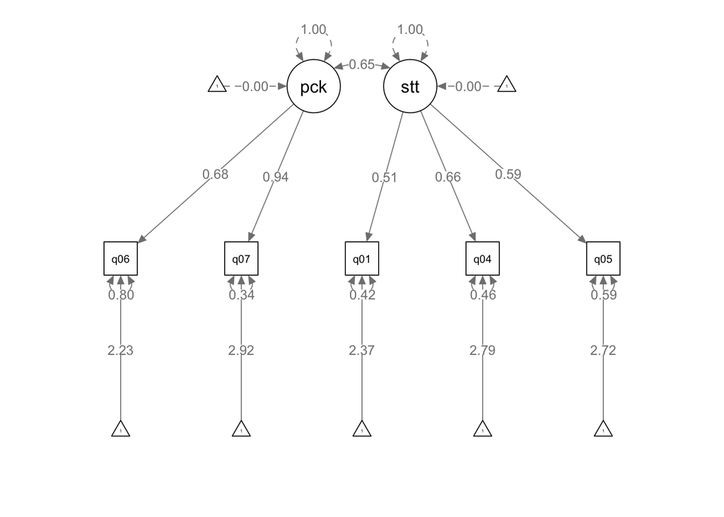

```r
semPaths(fits$Latecov2_intercept, whatLabel = "est", edge.label.cex = 0.9, residuals = TRUE)
```

```r
parameterEstimates(fits$Latecov2_intercept, standardized=TRUE) %>%
  filter(op == "=~") %>%
  select('Latent Fac'=lhs, Indicator=rhs, B=est, SE=se, Z=z, 'p-value'=pvalue, Beta=std.all) %>%
  kable(digits = 3, caption="Factor Loadings") %>%
  kable_styling(full_width = FALSE, bootstrap_options = c("striped", "hover", "responsive", "condensed"))
```

Factor Loadings

| Latent Fac | Indicator | B | SE | Z | p-value | Beta |
| --- | --- | --- | --- | --- | --- | --- |
| pcknow | q06 | 0.677 | 0.026 | 26.260 | 0 | 0.604 |
| pcknow | q07 | 0.938 | 0.028 | 32.956 | 0 | 0.851 |
| statknow | q01 | 0.512 | 0.018 | 28.704 | 0 | 0.619 |
| statknow | q04 | 0.661 | 0.020 | 32.333 | 0 | 0.697 |
| statknow | q05 | 0.587 | 0.021 | 28.220 | 0 | 0.609 |

**Model-Implied Variance-Covariance ($\hat{\Sigma}$)**

```r
fitted.values(fits$Latecov2)
```

```
## $cov
##     q06   q07   q01   q04   q05
## q06 1.258
## q07 0.635 1.215
## q01 0.225 0.312 0.685
## q04 0.290 0.402 0.339 0.899
## q05 0.258 0.357 0.301 0.388 0.930
```

**Sample Variance-Covariance Matrix (S)**

```r
pesquisa <- data.frame(dat1[,1:7])
cov_obs <- pesquisa %>%
  select(q06, q07, q01, q04, q05)

  round(cov(cov_obs),3)
```

```
##       q06   q07   q01   q04   q05
## q06 1.259 0.635 0.201 0.296 0.279
## q07 0.635 1.215 0.279 0.427 0.361
## q01 0.201 0.279 0.686 0.342 0.321
## q04 0.296 0.427 0.342 0.900 0.367
## q05 0.279 0.361 0.321 0.367 0.931
```

**Fitted Residual Matrix** (Unstandardized Residual Matrix) This is simply the difference between the observed and implied covariance matrix and mean vector.

```r
residuals(fits$Latecov2)
```

```
## $type
## [1] "raw"
##
## $cov
##     q06    q07    q01    q04    q05
## q06  0.000
## q07  0.000  0.000
## q01 -0.024 -0.033  0.000
## q04  0.006  0.025  0.004  0.000
## q05  0.021  0.004  0.020 -0.022  0.000
```

“cov.ov”:The model-implied variance-covariance matrix of the observed variables. The `lavInspect()` and `lavTech()` functions can be used to inspect/extract information that is stored inside (or can be computed from) a fitted lavaan object

```r
cor_table <- inspect(fits$Latecov2, "cov.ov")
cor_table
```

```
##     q06   q07   q01   q04   q05
## q06 1.258
## q07 0.635 1.215
## q01 0.225 0.312 0.685
## q04 0.290 0.402 0.339 0.899
## q05 0.258 0.357 0.301 0.388 0.930
```

lavInspect() on a fitted lavaan object returns a list of the model matrices that are used internally to represent the model. The free parameters are nonzero integers.

```r
lavInspect(fits$Latecov2)
```

```
## $lambda
##     pcknow sttknw
## q06      1      0
## q07      2      0
## q01      0      3
## q04      0      4
## q05      0      5
##
## $theta
##     q06 q07 q01 q04 q05
## q06  6
## q07  0   7
## q01  0   0   8
## q04  0   0   0   9
## q05  0   0   0   0  10
##
## $psi
##          pcknow sttknw
## pcknow    0
## statknow 11      0
```

Parameters

```r
parameterestimates(fits$Latecov2)
```

```
##         lhs op      rhs   est    se      z pvalue ci.lower ci.upper
## 1    pcknow =~      q06 0.677 0.026 26.260      0    0.627    0.728
## 2    pcknow =~      q07 0.938 0.028 32.956      0    0.882    0.993
## 3  statknow =~      q01 0.512 0.018 28.704      0    0.477    0.547
## 4  statknow =~      q04 0.661 0.020 32.333      0    0.621    0.701
## 5  statknow =~      q05 0.587 0.021 28.220      0    0.547    0.628
## 6    pcknow ~~   pcknow 1.000 0.000     NA     NA    1.000    1.000
## 7  statknow ~~ statknow 1.000 0.000     NA     NA    1.000    1.000
## 8       q06 ~~      q06 0.800 0.031 25.496      0    0.738    0.861
## 9       q07 ~~      q07 0.336 0.043  7.760      0    0.251    0.421
## 10      q01 ~~      q01 0.423 0.016 26.869      0    0.392    0.454
## 11      q04 ~~      q04 0.463 0.021 22.247      0    0.422    0.504
## 12      q05 ~~      q05 0.585 0.021 27.350      0    0.543    0.627
## 13   pcknow ~~ statknow 0.648 0.023 28.819      0    0.604    0.693
```

**Fit Mearures**

```r
fitmeasures(fits$Latecov2)
```

```
##                npar                fmin               chisq                  df
##              11.000               0.005              23.935               4.000
##              pvalue      baseline.chisq         baseline.df     baseline.pvalue
##               0.000            2634.246              10.000               0.000
##                 cfi                 tli                nnfi                 rfi
##               0.992               0.981               0.981               0.977
##                 nfi                pnfi                 ifi                 rni
##               0.991               0.396               0.992               0.992
##                logl   unrestricted.logl                 aic                 bic
##          -16765.895          -16753.928           33553.790           33618.163
##              ntotal                bic2               rmsea      rmsea.ci.lower
##            2571.000           33583.212               0.044               0.028
##      rmsea.ci.upper        rmsea.pvalue                 rmr          rmr_nomean
##               0.062               0.685               0.016               0.016
##                srmr        srmr_bentler srmr_bentler_nomean                crmr
##               0.017               0.017               0.017               0.020
##         crmr_nomean          srmr_mplus   srmr_mplus_nomean               cn_05
##               0.020               0.017               0.017            1020.150
##               cn_01                 gfi                agfi                pgfi
##            1427.153               0.996               0.986               0.266
##                 mfi                ecvi
##               0.996               0.018
```

# 7 References

[^1]: ALAVI, M., VISENTIN, D. C., THAPA, D. K., HUNT, G. E., WATSON, R., & CLEARY, M. L.. Chi-square for model fit in confirmatory factor analysis.2020.
[^2]: JOHNSON, Richard Arnold; WICHERN, Dean W. Applied multivariate statistical analysis. London, UK:: Pearson, 2014.
[^3]: JÖRESKOG, K. G. A general approach to confirmatory maximum likelihood factor analysis. Psychometrika, 34(2), 183–202. 1969. doi:10.1007/bf02289343
[^4]: BOLLEN, Kenneth A. Structural equations with latent variables. John Wiley & Sons, 1989.
[^5]: BEAUJEAN, A. Alexander. Latent variable modeling using R: A step-by-step guide. Routledge, 2014.
[^6]: BROWN, Timothy A. Confirmatory factor analysis for applied research. Guilford publications, 2015.
[^7]: FINCH, W. Holmes; FRENCH, Brian F. Latent variable modeling with R. Routledge, 2015.
[^8]: KLINE, Rex B. Principles and practice of structural equation modeling. Guilford publications, 2016.
[^9]: ALAVI, M., VISENTIN, D. C., THAPA, D. K., HUNT, G. E., WATSON, R., & CLEARY, M. L.. Chi-square for model fit in confirmatory factor analysis.2020.
[^10]: MACCALLUM, R. C., BROWNE, M. W., & SUGAWARA, H. M. Power analysis and determination of sample size for covariance structure modeling. Psychological Methods, 1, 130–149, 1996.